# Introducción a la Ciencia de Datos

## Proyecto 1

**Alumnos:** Sebastián Cadavid-Sánchez - Juan Pablo Herrera Musi

La base de datos que se utilizará contiene información sobre los procedimientos de interrupción legal del embarazo (ILE) que se realizaron en las clínicas y hospitales de la Secretaría de la Salud de la Ciudad d México a partir de 2016. Los datos son públicos y se encuentran en la página web de [Datos Abiertos Ciudad de México](https://datos.cdmx.gob.mx/explore/dataset/interrupcion-legal-del-embarazo/table/).

- *year* : Año en que se realizó el procedimiento
- *mes* : Mes en que se realizó el procedimiento
- _cve*hospital* : Clave de la Unidad Médica donde se realizó el procedimiento
- *fingreso* : Fecha de Interrupción Legal del Embarazo
- *autoref* : Especificar si la paciente es referida de otra unidad o acude directamente
- _edocivil*descripcion* : Estado civil
- **edad** : Edad cumplida en años
- _desc*derechohab* : Especificar la institución que otorga la derechohabiencia
- _nivel*edu* : Último nivel escola acreditado
- *ocupacion* : Ocupación
- *religion* : Religión
- *parentezco* : Parentesco del responsable con la paciente
- *entidad* : Entidad de residencia
- _alc_o*municipio* : Delegación o municipio de residencia
- *menarca* : Edad de la primera menstruación
- *fsexual* : Edad de inicio de vida sexual activa
- *fmenstrua* : Fecha de la última menstruación
- *sememb* : Semanas de embarazo por fecha de última menstruación
- *nhijos* : Número de hijos
- *gesta* : Número de embarazos (Incluyendo abortos)
- *naborto* : Número de abortos
- *npartos* : Número de nacimientos por vía vaginal
- *ncesarea* : Número de cesáreas
- *nile* : Número de Interrupciones Legales del Embarazo previas
- *consejeria* : Especificar si la paciente recibió consejería sobre la ILE
- *anticonceptivo* : Especificar si la paciente utiliza de forma habitual método anticonceptivo
- _c*num* : Número de consultas
- *motiles* : Motivo por el cual se desea la interrupción del embarazo
- _h*ingreso* : En caso de hospitalización, fecha de ingreso
- _desc*servicio* : Servicio en el que se otorgó la interrupción
- _p*semgest* : Semanas de gestación por USG
- _p*diasgesta* : Días de gestación por USG
- _p*consent* : Se requisitó y firmo el consentimiento informado
- *procile* : Método utilizado para la interrupción legal
- _s*complica* : Se presentaron complicaciones por el procedimiento
- *panticoncep* : Método anticonceptivo proporcionado post evento obstétrico

**Nota:** la variable de respuesta se transforma antes de partir el set de datos?

En el presente ejercicio de análisis estadístico se realiza el siguiente procedimiento:

- Inicialmente, se realiza la limpieza, y organización de la base de datos a utilizar.
- Se realiza un ejercicio de *data profiling* ,
- Se hace un ejercicio explorationio de los datos *(GEDA)* destacando las 5 características más importantes del conjunto de datos.
- Se realiza *feature engineering* para seleccionar las características más importantes para explicar la variable explicada.
- Luego, se genera un *magic loop* incluyendo un *hiperparameter tunning* con 3 modelos: Árbol, RandomForest, y XGBoost (`GradientBoostingClassifier`).
- De acuerdo al problema especificado y a métricas de ajuste a los datos se selecciona el mejor modelo seleccionado para predicción de la variable de respuesta.

### 1. Limpieza y transformación de la base de datos

```python
# paquetes propios
import load_data as ld
import clean_data as cd
import transform_data as td
import geda as geda

# paquetes externos
import pandas_profiling
import pandas as pd
import numpy as np
import matplotlib.pyplot as plt
pd.set_option('display.max_columns', None)

# importar base de datos
df = ld.read_data("interrupcion-legal-del-embarazo.csv", sep=";")
# vista previa de la base de datos inicial
df.head()
```

|  | AÑO | MES | CVE_HOSPITAL | FINGRESO | AUTOREF | EDOCIVIL_DESCRIPCION | EDAD | DESC_DERECHOHAB | NIVEL_EDU | OCUPACION | RELIGION | PARENTESCO | ENTIDAD | ALC O MUNICIPIO | MENARCA | FSEXUAL | FMENSTRUA | SEMEMB | NHIJOS | GESTA | NABORTO | NPARTOS | NCESAREA | NILE | CONSEJERIA | ANTICONCEPTIVO | C_NUM | MOTILES | H_FINGRESO | … |
| --- | --- | --- | --- | --- | --- | --- | --- | --- | --- | --- | --- | --- | --- | --- | --- | --- | --- | --- | --- | --- | --- | --- | --- | --- | --- | --- | --- | --- | --- | --- |
| 0 | 2016 | Enero | 10 | 12/01/16 | AUTORREFERIDA | soltera | 34 | ninguna | primaria completa | Desempleada | ninguna | Amiga | Estado de México | NaN | 11.0 | 17.0 | 16/11/15 | 7.0 | 1.0 | 3.0 | 0.0 | 0.0 | 1.0 | 1.0 | Si | Anticoncepcion de Emergencia | 2.0 | interrupción voluntaria | NE | … |
| 1 | 2016 | Abril | 1 | 25/04/16 | no | unión libre | 27 | ninguna | licenciatura completa | Mesera | ninguna | Pareja | Ciudad de México | iztapalapa | 11.0 | 18.0 | 25/02/16 | 8.4 | 1.0 | 3.0 | 0.0 | 1.0 | 1.0 | 0.0 | Si | Condón | NaN | interrupción voluntaria | 25/04/16 | … |
| 2 | 2018 | Julio | 4 | 11/07/18 | NaN | soltera | 29 | ninguna | secundaria completa | Trabajadora del Sector Público | ninguna | NaN | Estado de México | nezahualcóyotl | 11.0 | 15.0 | 18/05/18 | 7.0 | 3.0 | 4.0 | 0.0 | 3.0 | 0.0 | 0.0 | Si | DIU | 2.0 | interrupción voluntaria | NE | … |
| 3 | 2016 | Enero | 10 | 07/01/16 | AUTORREFERIDA | casada | 33 | ninguna | preparatoria completa | Ama de Casa | católica | Conyuge | Estado de México | coacalco | 15.0 | 17.0 | 16/11/15 | 7.4 | 2.0 | 4.0 | 1.0 | 2.0 | 0.0 | 0.0 | Si | Ninguno | 2.0 | interrupción voluntaria | NE | … |
| 4 | 2018 | Agosto | 7 | NaN | no | unión libre | 23 | N/E | preparatoria completa | NaN | católica | NaN | Ciudad de México | álvaro obregón | 12.0 | 16.0 | NaN | NaN | 1.0 | 2.0 | 0.0 | 1.0 | 0.0 | 0.0 | Si | Condón | 2.0 | interrupción voluntaria | 24/08/18 | … |

Como se observa en la anterior visualización, en la base de datos existen tanto variables numéricas como categóricas y de fechas. Adicionalmente, algunas variables categórico no tienen un formato estándar (mezcla de mayúsculas y minúsculas, espacios, acentos, etc). A continuación se realizará la estandarización y limpieza de las anteriores variables para tener un mejor manejo de la base de datos.

**1.1** Limpieza de los nombres de las columnas: Sin expacios, sin caracteres extraños, sin acentos, y en minúsculas.

```python
df = cd.clean_column_names(df)
df.columns=df.columns.str.replace('ñ', 'n')
df.head(1)
```

|  | ano | mes | cve_hospital | fingreso | autoref | edocivil_descripcion | edad | desc_derechohab | nivel_edu | ocupacion | religion | parentesco | entidad | alc_o_municipio | menarca | fsexual | fmenstrua | sememb | nhijos | gesta | naborto | npartos | ncesarea | nile | consejeria | anticonceptivo | c_num | motiles | h_fingreso | … |
| --- | --- | --- | --- | --- | --- | --- | --- | --- | --- | --- | --- | --- | --- | --- | --- | --- | --- | --- | --- | --- | --- | --- | --- | --- | --- | --- | --- | --- | --- | --- |
| 0 | 2016 | Enero | 10 | 12/01/16 | AUTORREFERIDA | soltera | 34 | ninguna | primaria completa | Desempleada | ninguna | Amiga | Estado de México | NaN | 11.0 | 17.0 | 16/11/15 | 7.0 | 1.0 | 3.0 | 0.0 | 0.0 | 1.0 | 1.0 | Si | Anticoncepcion de Emergencia | 2.0 | interrupción voluntaria | NE | … |

**1.2** Limpieza de los datos: Si están en mayúsculas cambiar a minúsculas, quitar acentos, etc.

```python
# variables categóricas
cols_categorical = ["mes",
                 "autoref",
                 "edocivil_descripcion",
                 "desc_derechohab",
                 "nivel_edu",
                 "ocupacion",
                 "religion",
                 "parentesco",
                 "entidad",
                 "alc_o_municipio",
                 "consejeria",
                 "anticonceptivo",
                 "motiles",
                 "desc_servicio",
                 "p_consent",
                 "procile",
                 "s_complica",
                 "panticoncep"]

# convertir columnas a minúsculas
df = td.to_lowercase(df, cols_categorical)
# quitar acentos
for stringVar in cols_categorical:
    df = td.remove_special_char(df, stringVar)
df.head()
```

|  | ano | mes | cve_hospital | fingreso | autoref | edocivil_descripcion | edad | desc_derechohab | nivel_edu | ocupacion | religion | parentesco | entidad | alc_o_municipio | menarca | fsexual | fmenstrua | sememb | nhijos | gesta | naborto | npartos | ncesarea | nile | consejeria | anticonceptivo | c_num | motiles | h_fingreso | … |
| --- | --- | --- | --- | --- | --- | --- | --- | --- | --- | --- | --- | --- | --- | --- | --- | --- | --- | --- | --- | --- | --- | --- | --- | --- | --- | --- | --- | --- | --- | --- |
| 0 | 2016 | enero | 10 | 12/01/16 | autorreferida | soltera | 34 | ninguna | primaria_completa | desempleada | ninguna | amiga | estado_de_mexico | NaN | 11.0 | 17.0 | 16/11/15 | 7.0 | 1.0 | 3.0 | 0.0 | 0.0 | 1.0 | 1.0 | si | anticoncepcion_de_emergencia | 2.0 | interrupcion_voluntaria | NE | … |
| 1 | 2016 | abril | 1 | 25/04/16 | no | union_libre | 27 | ninguna | licenciatura_completa | mesera | ninguna | pareja | ciudad_de_mexico | iztapalapa | 11.0 | 18.0 | 25/02/16 | 8.4 | 1.0 | 3.0 | 0.0 | 1.0 | 1.0 | 0.0 | si | condon | NaN | interrupcion_voluntaria | 25/04/16 | … |
| 2 | 2018 | julio | 4 | 11/07/18 | NaN | soltera | 29 | ninguna | secundaria_completa | trabajadora_del_sector_publico | ninguna | NaN | estado_de_mexico | nezahualcoyotl | 11.0 | 15.0 | 18/05/18 | 7.0 | 3.0 | 4.0 | 0.0 | 3.0 | 0.0 | 0.0 | si | diu | 2.0 | interrupcion_voluntaria | NE | … |
| 3 | 2016 | enero | 10 | 07/01/16 | autorreferida | casada | 33 | ninguna | preparatoria_completa | ama_de_casa | catolica | conyuge | estado_de_mexico | coacalco | 15.0 | 17.0 | 16/11/15 | 7.4 | 2.0 | 4.0 | 1.0 | 2.0 | 0.0 | 0.0 | si | ninguno | 2.0 | interrupcion_voluntaria | NE | … |
| 4 | 2018 | agosto | 7 | NaN | no | union_libre | 23 | n/e | preparatoria_completa | NaN | catolica | NaN | ciudad_de_mexico | alvaro_obregon | 12.0 | 16.0 | NaN | NaN | 1.0 | 2.0 | 0.0 | 1.0 | 0.0 | 0.0 | si | condon | 2.0 | interrupcion_voluntaria | 24/08/18 | … |

**1.3** Cambiar a los tipos de datos adecuados -si es necesario-.

```python
# convertir todas las categóricas a su tipo
for var in cols_categorical:
    df[var] = df[var].astype('category')

# cambiar clave de hospital y ano a categórica
addcategorical_vars = ["cve_hospital", "ano"]

for var in addcategorical_vars:
    df[var] = df[var].astype('category')

# sea crea la variable de respuesta
df["mayor_23"] = np.where(df["edad"]>=24,1,0)

# tipos de variables
# geda.tipos_variables(df)
df.info()
```

```
<class 'pandas.core.frame.DataFrame'>
RangeIndex: 62003 entries, 0 to 62002
Data columns (total 37 columns):
ano                     62003 non-null category
mes                     62003 non-null category
cve_hospital            62003 non-null category
fingreso                60420 non-null object
autoref                 16874 non-null category
edocivil_descripcion    61887 non-null category
edad                    62003 non-null int64
desc_derechohab         54962 non-null category
nivel_edu               60719 non-null category
ocupacion               54282 non-null category
religion                60183 non-null category
parentesco              20163 non-null category
entidad                 61983 non-null category
alc_o_municipio         57910 non-null category
menarca                 59114 non-null float64
fsexual                 57750 non-null float64
fmenstrua               55299 non-null object
sememb                  58403 non-null float64
nhijos                  58794 non-null float64
gesta                   59341 non-null float64
naborto                 57888 non-null float64
npartos                 58240 non-null float64
ncesarea                57904 non-null float64
nile                    49598 non-null float64
consejeria              60047 non-null category
anticonceptivo          55297 non-null category
c_num                   41725 non-null float64
motiles                 60915 non-null category
h_fingreso              54466 non-null object
desc_servicio           57788 non-null category
p_semgest               61974 non-null float64
p_diasgesta             48602 non-null float64
p_consent               17856 non-null category
procile                 60290 non-null category
s_complica              32768 non-null category
panticoncep             45199 non-null category
mayor_23                62003 non-null int64
dtypes: category(20), float64(12), int64(2), object(3)
memory usage: 9.3+ MB
```

**1.4** Data profiling Para realizar el *data profiling* se utilizó el paquete `pandas_profiling`. El reporte se presenta a continuación.

Overview

Dataset info

| Number of variables | 37 |
| --- | --- |
| Number of observations | 62003 |
| Total Missing (%) | 13.3% |
| Total size in memory | 9.1 MiB |
| Average record size in memory | 153.7 B |

Variables types

| Numeric | 13 |
| --- | --- |
| Categorical | 23 |
| Boolean | 1 |
| Date | 0 |
| Text (Unique) | 0 |
| Rejected | 0 |
| Unsupported | 0 |

Warnings

- `fingreso` has 1583 / 2.6% missing values Missing

- `fingreso` has a high cardinality: 937 distinct values Warning

- `autoref` has 45129 / 72.8% missing values Missing

- `desc_derechohab` has 7041 / 11.4% missing values Missing

- `nivel_edu` has 1284 / 2.1% missing values Missing

- `ocupacion` has 7721 / 12.5% missing values Missing

- `ocupacion` has a high cardinality: 54 distinct values Warning

- `religion` has 1820 / 2.9% missing values Missing

- `parentesco` has 41840 / 67.5% missing values Missing

- `alc_o_municipio` has 4093 / 6.6% missing values Missing

- `alc_o_municipio` has a high cardinality: 497 distinct values Warning

- `menarca` has 2889 / 4.7% missing values Missing

- `fsexual` has 4253 / 6.9% missing values Missing

- `fmenstrua` has 6704 / 10.8% missing values Missing

- `fmenstrua` has a high cardinality: 1509 distinct values Warning

- `sememb` has 3600 / 5.8% missing values Missing

- `nhijos` has 3209 / 5.2% missing values Missing

- `nhijos` has 24772 / 40.0% zeros Zeros

- `gesta` has 2662 / 4.3% missing values Missing

- `gesta` has 743 / 1.2% zeros Zeros

- `naborto` has 4115 / 6.6% missing values Missing

- `naborto` has 49312 / 79.5% zeros Zeros

- `npartos` has 3763 / 6.1% missing values Missing

- `npartos` has 35042 / 56.5% zeros Zeros

- `ncesarea` has 4099 / 6.6% missing values Missing

- `ncesarea` has 43462 / 70.1% zeros Zeros

- `nile` has 12405 / 20.0% missing values Missing

- `nile` has 42370 / 68.3% zeros Zeros

- `consejeria` has 1956 / 3.2% missing values Missing

- `anticonceptivo` has 6706 / 10.8% missing values Missing

- `c_num` has 20278 / 32.7% missing values Missing

- `motiles` has 1088 / 1.8% missing values Missing

- `h_fingreso` has 7537 / 12.2% missing values Missing

- `h_fingreso` has a high cardinality: 583 distinct values Warning

- `desc_servicio` has 4215 / 6.8% missing values Missing

- `p_diasgesta` has 13401 / 21.6% missing values Missing

- `p_diasgesta` has 4006 / 6.5% zeros Zeros

- `p_consent` has 44147 / 71.2% missing values Missing

- `procile` has 1713 / 2.8% missing values Missing

- `s_complica` has 29235 / 47.2% missing values Missing

- `panticoncep` has 16804 / 27.1% missing values Missing

Variables

ano  
Categorical

| Distinct count | 4 |
| --- | --- |
| Unique (%) | 0.0% |
| Missing (%) | 0.0% |
| Missing (n) | 0 |

| 2016 | 18084 |
| --- | --- |
| 2017 | 17588 |
| 2018 | 17247 |

Toggle details

| Value | Count | Frequency (%) |  |
| --- | --- | --- | --- |
| 2016 | 18084 | 29.2% |  |
| 2017 | 17588 | 28.4% |  |
| 2018 | 17247 | 27.8% |  |
| 2019 | 9084 | 14.7% |  |

mes  
Categorical

| Distinct count | 12 |
| --- | --- |
| Unique (%) | 0.0% |
| Missing (%) | 0.0% |
| Missing (n) | 0 |

| enero | 6201 |
| --- | --- |
| mayo | 6100 |
| marzo | 5970 |
| Other values (9) | 43732 |

Toggle details

| Value | Count | Frequency (%) |  |
| --- | --- | --- | --- |
| enero | 6201 | 10.0% |  |
| mayo | 6100 | 9.8% |  |
| marzo | 5970 | 9.6% |  |
| junio | 5736 | 9.3% |  |
| febrero | 5631 | 9.1% |  |
| abril | 5569 | 9.0% |  |
| julio | 5568 | 9.0% |  |
| octubre | 4775 | 7.7% |  |
| agosto | 4724 | 7.6% |  |
| septiembre | 4202 | 6.8% |  |
| Other values (2) | 7527 | 12.1% |  |

cve_hospital  
Categorical

| Distinct count | 14 |
| --- | --- |
| Unique (%) | 0.0% |
| Missing (%) | 0.0% |
| Missing (n) | 0 |

| 2 | 14108 |
| --- | --- |
| 5 | 12783 |
| 4 | 9913 |
| Other values (11) | 25199 |

Toggle details

| Value | Count | Frequency (%) |  |
| --- | --- | --- | --- |
| 2 | 14108 | 22.8% |  |
| 5 | 12783 | 20.6% |  |
| 4 | 9913 | 16.0% |  |
| 1 | 7648 | 12.3% |  |
| 11 | 3380 | 5.5% |  |
| 12 | 2583 | 4.2% |  |
| 7 | 2455 | 4.0% |  |
| 10 | 2270 | 3.7% |  |
| 8 | 1915 | 3.1% |  |
| 13 | 1671 | 2.7% |  |
| Other values (4) | 3277 | 5.3% |  |

fingreso  
Categorical

| Distinct count | 937 |
| --- | --- |
| Unique (%) | 1.5% |
| Missing (%) | 2.6% |
| Missing (n) | 1583 |

| 28/09/16 | 128 |
| --- | --- |
| 09/01/18 | 120 |
| 17/01/19 | 113 |
| Other values (933) | 60059 |
| (Missing) | 1583 |

Toggle details

| Value | Count | Frequency (%) |  |
| --- | --- | --- | --- |
| 28/09/16 | 128 | 0.2% |  |
| 09/01/18 | 120 | 0.2% |  |
| 17/01/19 | 113 | 0.2% |  |
| 04/11/16 | 109 | 0.2% |  |
| 11/09/17 | 105 | 0.2% |  |
| 12/01/18 | 104 | 0.2% |  |
| 20/01/17 | 103 | 0.2% |  |
| 26/02/16 | 103 | 0.2% |  |
| 19/04/16 | 102 | 0.2% |  |
| 22/03/18 | 101 | 0.2% |  |
| Other values (926) | 59332 | 95.7% |  |
| (Missing) | 1583 | 2.6% |  |

autoref  
Categorical

| Distinct count | 34 |
| --- | --- |
| Unique (%) | 0.1% |
| Missing (%) | 72.8% |
| Missing (n) | 45129 |

| autorreferida | 10887 |
| --- | --- |
| no | 4268 |
| autoreferida | 991 |
| Other values (30) | 728 |
| (Missing) | 45129 |

Toggle details

| Value | Count | Frequency (%) |  |
| --- | --- | --- | --- |
| autorreferida | 10887 | 17.6% |  |
| no | 4268 | 6.9% |  |
| autoreferida | 991 | 1.6% |  |
| no_especificado | 670 | 1.1% |  |
| cst_iii_ampliacion_hidalgo | 6 | 0.0% |  |
| cst_iii_dr_angel_de_garza_brito | 6 | 0.0% |  |
| cst_i_dif | 5 | 0.0% |  |
| cst_iii_pedregal_de_las_aguilas | 5 | 0.0% |  |
| cst_ii_cultura_maya | 4 | 0.0% |  |
| cst_iii_jose_castro_villagrana | 4 | 0.0% |  |
| Other values (23) | 28 | 0.0% |  |
| (Missing) | 45129 | 72.8% |  |

edocivil_descripcion  
Categorical

| Distinct count | 8 |
| --- | --- |
| Unique (%) | 0.0% |
| Missing (%) | 0.2% |
| Missing (n) | 116 |

| soltera | 34423 |
| --- | --- |
| union_libre | 17714 |
| casada | 6517 |
| Other values (4) | 3233 |

Toggle details

| Value | Count | Frequency (%) |  |
| --- | --- | --- | --- |
| soltera | 34423 | 55.5% |  |
| union_libre | 17714 | 28.6% |  |
| casada | 6517 | 10.5% |  |
| divorciada | 1567 | 2.5% |  |
| separada | 916 | 1.5% |  |
| n/e | 570 | 0.9% |  |
| viuda | 180 | 0.3% |  |
| (Missing) | 116 | 0.2% |  |

edad  
Numeric

| Distinct count | 43 |
| --- | --- |
| Unique (%) | 0.1% |
| Missing (%) | 0.0% |
| Missing (n) | 0 |
| Infinite (%) | 0.0% |
| Infinite (n) | 0 |

| Mean | 25.695 |
| --- | --- |
| Minimum | 11 |
| Maximum | 53 |
| Zeros (%) | 0.0% |

Toggle details

**Statistics**

Quantile statistics

| Minimum | 11 |
| --- | --- |
| 5-th percentile | 18 |
| Q1 | 21 |
| Median | 24 |
| Q3 | 30 |
| 95-th percentile | 38 |
| Maximum | 53 |
| Range | 42 |
| Interquartile range | 9 |

Descriptive statistics

| Standard deviation | 6.2802 |
| --- | --- |
| Coef of variation | 0.24441 |
| Kurtosis | 0.015287 |
| Mean | 25.695 |
| MAD | 5.0634 |
| Skewness | 0.70232 |
| Sum | 1593195 |
| Variance | 39.441 |
| Memory size | 484.5 KiB |

**Histogram**

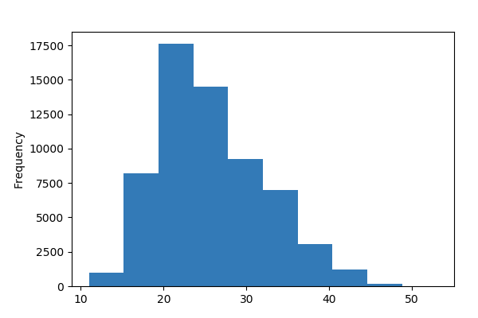

**Common Values**

| Value | Count | Frequency (%) |  |
| --- | --- | --- | --- |
| 22 | 4499 | 7.3% |  |
| 23 | 4497 | 7.3% |  |
| 21 | 4488 | 7.2% |  |
| 24 | 4196 | 6.8% |  |
| 20 | 4129 | 6.7% |  |
| 25 | 3868 | 6.2% |  |
| 19 | 3496 | 5.6% |  |
| 26 | 3434 | 5.5% |  |
| 27 | 3012 | 4.9% |  |
| 28 | 2760 | 4.5% |  |
| Other values (33) | 23624 | 38.1% |  |

**Extreme Values**

Minimum 5 values

| Value | Count | Frequency (%) |  |
| --- | --- | --- | --- |
| 11 | 3 | 0.0% |  |
| 12 | 18 | 0.0% |  |
| 13 | 86 | 0.1% |  |
| 14 | 270 | 0.4% |  |
| 15 | 601 | 1.0% |  |

Maximum 5 values

| Value | Count | Frequency (%) |  |
| --- | --- | --- | --- |
| 49 | 2 | 0.0% |  |
| 50 | 1 | 0.0% |  |
| 51 | 1 | 0.0% |  |
| 52 | 2 | 0.0% |  |
| 53 | 2 | 0.0% |  |

desc_derechohab  
Categorical

| Distinct count | 35 |
| --- | --- |
| Unique (%) | 0.1% |
| Missing (%) | 11.4% |
| Missing (n) | 7041 |

| ninguna | 31771 |
| --- | --- |
| gratuidad | 8521 |
| imss | 4839 |
| Other values (31) | 9831 |
| (Missing) | 7041 |

Toggle details

| Value | Count | Frequency (%) |  |
| --- | --- | --- | --- |
| ninguna | 31771 | 51.2% |  |
| gratuidad | 8521 | 13.7% |  |
| imss | 4839 | 7.8% |  |
| seguro_popular | 4623 | 7.5% |  |
| n/e | 3093 | 5.0% |  |
| issste | 853 | 1.4% |  |
| cuota | 376 | 0.6% |  |
| otro | 363 | 0.6% |  |
| particular | 144 | 0.2% |  |
| pago | 125 | 0.2% |  |
| Other values (24) | 254 | 0.4% |  |
| (Missing) | 7041 | 11.4% |  |

nivel_edu  
Categorical

| Distinct count | 18 |
| --- | --- |
| Unique (%) | 0.0% |
| Missing (%) | 2.1% |
| Missing (n) | 1284 |

| preparatoria_completa | 27078 |
| --- | --- |
| secundaria_completa | 17734 |
| licenciatura_completa | 10025 |
| Other values (14) | 5882 |

Toggle details

| Value | Count | Frequency (%) |  |
| --- | --- | --- | --- |
| preparatoria_completa | 27078 | 43.7% |  |
| secundaria_completa | 17734 | 28.6% |  |
| licenciatura_completa | 10025 | 16.2% |  |
| primaria_completa | 2853 | 4.6% |  |
| preparatoria_incompleta | 1065 | 1.7% |  |
| ninguno | 554 | 0.9% |  |
| licenciatura_incompleta | 382 | 0.6% |  |
| no_especifica | 342 | 0.6% |  |
| secundaria_incompleta | 208 | 0.3% |  |
| maestria | 183 | 0.3% |  |
| Other values (7) | 295 | 0.5% |  |
| (Missing) | 1284 | 2.1% |  |

ocupacion  
Categorical

| Distinct count | 54 |
| --- | --- |
| Unique (%) | 0.1% |
| Missing (%) | 12.5% |
| Missing (n) | 7721 |

| estudiante | 15689 |
| --- | --- |
| empleada | 11165 |
| ama_de_casa | 10235 |
| Other values (50) | 17193 |
| (Missing) | 7721 |

Toggle details

| Value | Count | Frequency (%) |  |
| --- | --- | --- | --- |
| estudiante | 15689 | 25.3% |  |
| empleada | 11165 | 18.0% |  |
| ama_de_casa | 10235 | 16.5% |  |
| trabajadora_del_sector_publico | 5791 | 9.3% |  |
| comerciante | 3719 | 6.0% |  |
| mesera | 3340 | 5.4% |  |
| desempleada | 3241 | 5.2% |  |
| estilista | 141 | 0.2% |  |
| profesora_o_educadora | 129 | 0.2% |  |
| trabajadora_del_hogar | 107 | 0.2% |  |
| Other values (43) | 725 | 1.2% |  |
| (Missing) | 7721 | 12.5% |  |

religion  
Categorical

| Distinct count | 14 |
| --- | --- |
| Unique (%) | 0.0% |
| Missing (%) | 2.9% |
| Missing (n) | 1820 |

| catolica | 40295 |
| --- | --- |
| ninguna | 17515 |
| creyente | 1436 |
| Other values (10) | 937 |
| (Missing) | 1820 |

Toggle details

| Value | Count | Frequency (%) |  |
| --- | --- | --- | --- |
| catolica | 40295 | 65.0% |  |
| ninguna | 17515 | 28.2% |  |
| creyente | 1436 | 2.3% |  |
| cristiana | 649 | 1.0% |  |
| otra | 86 | 0.1% |  |
| mormon | 80 | 0.1% |  |
| budista | 50 | 0.1% |  |
| testigos_de_jeohva | 33 | 0.1% |  |
| evangelica | 26 | 0.0% |  |
| agnostica | 6 | 0.0% |  |
| Other values (3) | 7 | 0.0% |  |
| (Missing) | 1820 | 2.9% |  |

parentesco  
Categorical

| Distinct count | 41 |
| --- | --- |
| Unique (%) | 0.1% |
| Missing (%) | 67.5% |
| Missing (n) | 41840 |

| madre | 4463 |
| --- | --- |
| pareja | 3287 |
| esposo | 2783 |
| Other values (37) | 9630 |
| (Missing) | 41840 |

Toggle details

| Value | Count | Frequency (%) |  |
| --- | --- | --- | --- |
| madre | 4463 | 7.2% |  |
| pareja | 3287 | 5.3% |  |
| esposo | 2783 | 4.5% |  |
| amiga | 1678 | 2.7% |  |
| hermana | 1326 | 2.1% |  |
| novio | 1289 | 2.1% |  |
| amigo | 837 | 1.3% |  |
| concubino | 808 | 1.3% |  |
| otro_u_otra | 673 | 1.1% |  |
| prima | 495 | 0.8% |  |
| Other values (30) | 2524 | 4.1% |  |
| (Missing) | 41840 | 67.5% |  |

entidad  
Categorical

| Distinct count | 33 |
| --- | --- |
| Unique (%) | 0.1% |
| Missing (%) | 0.0% |
| Missing (n) | 20 |

| ciudad_de_mexico | 39349 |
| --- | --- |
| estado_de_mexico | 19533 |
| hidalgo | 467 |
| Other values (29) | 2634 |

Toggle details

| Value | Count | Frequency (%) |  |
| --- | --- | --- | --- |
| ciudad_de_mexico | 39349 | 63.5% |  |
| estado_de_mexico | 19533 | 31.5% |  |
| hidalgo | 467 | 0.8% |  |
| puebla | 464 | 0.7% |  |
| morelos | 303 | 0.5% |  |
| jalisco | 237 | 0.4% |  |
| queretaro | 235 | 0.4% |  |
| veracruz | 205 | 0.3% |  |
| michoacan | 163 | 0.3% |  |
| guanajuato | 151 | 0.2% |  |
| Other values (22) | 876 | 1.4% |  |

alc_o_municipio  
Categorical

| Distinct count | 497 |
| --- | --- |
| Unique (%) | 0.8% |
| Missing (%) | 6.6% |
| Missing (n) | 4093 |

| iztapalapa | 7776 |
| --- | --- |
| gustavo_a_madero | 5983 |
| venustiano_carranza | 3573 |
| Other values (493) | 40578 |
| (Missing) | 4093 |

Toggle details

| Value | Count | Frequency (%) |  |
| --- | --- | --- | --- |
| iztapalapa | 7776 | 12.5% |  |
| gustavo_a_madero | 5983 | 9.6% |  |
| venustiano_carranza | 3573 | 5.8% |  |
| ecatepec_de_morelos | 3433 | 5.5% |  |
| alvaro_obregon | 2925 | 4.7% |  |
| cuauhtemoc | 2878 | 4.6% |  |
| nezahualcoyotl | 2692 | 4.3% |  |
| azcapotzalco | 2368 | 3.8% |  |
| iztacalco | 2067 | 3.3% |  |
| mighel_hidalgo | 1797 | 2.9% |  |
| Other values (486) | 22418 | 36.2% |  |
| (Missing) | 4093 | 6.6% |  |

menarca  
Numeric

| Distinct count | 28 |
| --- | --- |
| Unique (%) | 0.0% |
| Missing (%) | 4.7% |
| Missing (n) | 2889 |
| Infinite (%) | 0.0% |
| Infinite (n) | 0 |

| Mean | 12.64 |
| --- | --- |
| Minimum | 1 |
| Maximum | 30 |
| Zeros (%) | 0.0% |

Toggle details

**Statistics**

Quantile statistics

| Minimum | 1 |
| --- | --- |
| 5-th percentile | 10 |
| Q1 | 12 |
| Median | 12 |
| Q3 | 14 |
| 95-th percentile | 16 |
| Maximum | 30 |
| Range | 29 |
| Interquartile range | 2 |

Descriptive statistics

| Standard deviation | 1.7538 |
| --- | --- |
| Coef of variation | 0.13875 |
| Kurtosis | 1.5145 |
| Mean | 12.64 |
| MAD | 1.3874 |
| Skewness | 0.23398 |
| Sum | 747200 |
| Variance | 3.0758 |
| Memory size | 484.5 KiB |

**Histogram**

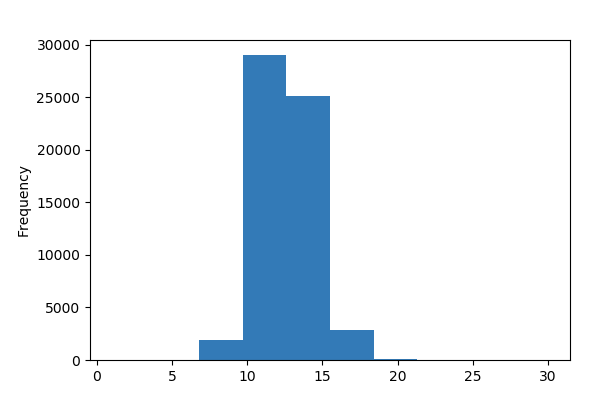

**Common Values**

| Value | Count | Frequency (%) |  |
| --- | --- | --- | --- |
| 12.0 | 17161 | 27.7% |  |
| 13.0 | 10912 | 17.6% |  |
| 11.0 | 9022 | 14.6% |  |
| 14.0 | 8114 | 13.1% |  |
| 15.0 | 6120 | 9.9% |  |
| 10.0 | 2827 | 4.6% |  |
| 16.0 | 1935 | 3.1% |  |
| 9.0 | 1679 | 2.7% |  |
| 17.0 | 634 | 1.0% |  |
| 18.0 | 309 | 0.5% |  |
| Other values (17) | 401 | 0.6% |  |
| (Missing) | 2889 | 4.7% |  |

**Extreme Values**

Minimum 5 values

| Value | Count | Frequency (%) |  |
| --- | --- | --- | --- |
| 1.0 | 14 | 0.0% |  |
| 2.0 | 7 | 0.0% |  |
| 3.0 | 7 | 0.0% |  |
| 4.0 | 2 | 0.0% |  |
| 5.0 | 6 | 0.0% |  |

Maximum 5 values

| Value | Count | Frequency (%) |  |
| --- | --- | --- | --- |
| 23.0 | 1 | 0.0% |  |
| 24.0 | 1 | 0.0% |  |
| 26.0 | 1 | 0.0% |  |
| 29.0 | 2 | 0.0% |  |
| 30.0 | 1 | 0.0% |  |

fsexual  
Numeric

| Distinct count | 45 |
| --- | --- |
| Unique (%) | 0.1% |
| Missing (%) | 6.9% |
| Missing (n) | 4253 |
| Infinite (%) | 0.0% |
| Infinite (n) | 0 |

| Mean | 16.979 |
| --- | --- |
| Minimum | 0 |
| Maximum | 54 |
| Zeros (%) | 0.1% |

Toggle details

**Statistics**

Quantile statistics

| Minimum | 0 |
| --- | --- |
| 5-th percentile | 14 |
| Q1 | 15 |
| Median | 17 |
| Q3 | 18 |
| 95-th percentile | 21 |
| Maximum | 54 |
| Range | 54 |
| Interquartile range | 3 |

Descriptive statistics

| Standard deviation | 2.4609 |
| --- | --- |
| Coef of variation | 0.14494 |
| Kurtosis | 8.6063 |
| Mean | 16.979 |
| MAD | 1.7334 |
| Skewness | 0.65939 |
| Sum | 980520 |
| Variance | 6.0563 |
| Memory size | 484.5 KiB |

**Histogram**

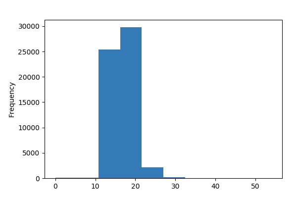

**Common Values**

| Value | Count | Frequency (%) |  |
| --- | --- | --- | --- |
| 18.0 | 10811 | 17.4% |  |
| 17.0 | 10531 | 17.0% |  |
| 16.0 | 10112 | 16.3% |  |
| 15.0 | 9925 | 16.0% |  |
| 19.0 | 4475 | 7.2% |  |
| 14.0 | 3712 | 6.0% |  |
| 20.0 | 2579 | 4.2% |  |
| 21.0 | 1373 | 2.2% |  |
| 13.0 | 1224 | 2.0% |  |
| 22.0 | 917 | 1.5% |  |
| Other values (34) | 2091 | 3.4% |  |
| (Missing) | 4253 | 6.9% |  |

**Extreme Values**

Minimum 5 values

| Value | Count | Frequency (%) |  |
| --- | --- | --- | --- |
| 0.0 | 61 | 0.1% |  |
| 1.0 | 22 | 0.0% |  |
| 2.0 | 15 | 0.0% |  |
| 3.0 | 4 | 0.0% |  |
| 4.0 | 4 | 0.0% |  |

Maximum 5 values

| Value | Count | Frequency (%) |  |
| --- | --- | --- | --- |
| 39.0 | 1 | 0.0% |  |
| 40.0 | 1 | 0.0% |  |
| 41.0 | 1 | 0.0% |  |
| 42.0 | 1 | 0.0% |  |
| 54.0 | 1 | 0.0% |  |

fmenstrua  
Categorical

| Distinct count | 1509 |
| --- | --- |
| Unique (%) | 2.4% |
| Missing (%) | 10.8% |
| Missing (n) | 6704 |

| 15/11/17 | 118 |
| --- | --- |
| 15/08/16 | 117 |
| 15/09/17 | 107 |
| Other values (1505) | 54957 |
| (Missing) | 6704 |

Toggle details

| Value | Count | Frequency (%) |  |
| --- | --- | --- | --- |
| 15/11/17 | 118 | 0.2% |  |
| 15/08/16 | 117 | 0.2% |  |
| 15/09/17 | 107 | 0.2% |  |
| 15/07/16 | 105 | 0.2% |  |
| 15/09/16 | 104 | 0.2% |  |
| 15/08/17 | 103 | 0.2% |  |
| 15/05/17 | 102 | 0.2% |  |
| 20/11/17 | 101 | 0.2% |  |
| 15/12/15 | 100 | 0.2% |  |
| 15/12/17 | 99 | 0.2% |  |
| Other values (1498) | 54243 | 87.5% |  |
| (Missing) | 6704 | 10.8% |  |

sememb  
Numeric

| Distinct count | 141 |
| --- | --- |
| Unique (%) | 0.2% |
| Missing (%) | 5.8% |
| Missing (n) | 3600 |
| Infinite (%) | 0.0% |
| Infinite (n) | 0 |

| Mean | 7.4398 |
| --- | --- |
| Minimum | 0 |
| Maximum | 50 |
| Zeros (%) | 1.0% |

Toggle details

**Statistics**

Quantile statistics

| Minimum | 0 |
| --- | --- |
| 5-th percentile | 4 |
| Q1 | 6 |
| Median | 7 |
| Q3 | 9 |
| 95-th percentile | 11 |
| Maximum | 50 |
| Range | 50 |
| Interquartile range | 3 |

Descriptive statistics

| Standard deviation | 2.3687 |
| --- | --- |
| Coef of variation | 0.31838 |
| Kurtosis | 19.226 |
| Mean | 7.4398 |
| MAD | 1.7354 |
| Skewness | 1.5775 |
| Sum | 434500 |
| Variance | 5.6107 |
| Memory size | 484.5 KiB |

**Histogram**

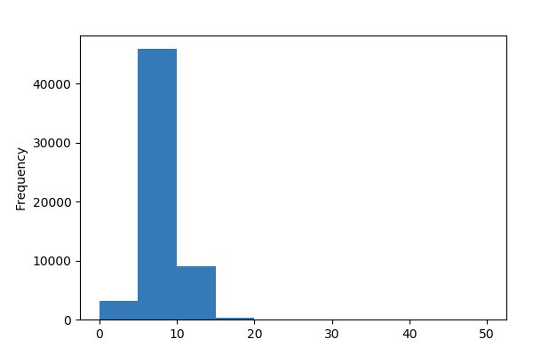

**Common Values**

| Value | Count | Frequency (%) |  |
| --- | --- | --- | --- |
| 7.0 | 10507 | 16.9% |  |
| 6.0 | 10106 | 16.3% |  |
| 8.0 | 8205 | 13.2% |  |
| 9.0 | 6017 | 9.7% |  |
| 5.0 | 5670 | 9.1% |  |
| 10.0 | 4080 | 6.6% |  |
| 11.0 | 2559 | 4.1% |  |
| 4.0 | 1692 | 2.7% |  |
| 12.0 | 1154 | 1.9% |  |
| 0.0 | 597 | 1.0% |  |
| Other values (130) | 7816 | 12.6% |  |
| (Missing) | 3600 | 5.8% |  |

**Extreme Values**

Minimum 5 values

| Value | Count | Frequency (%) |  |
| --- | --- | --- | --- |
| 0.0 | 597 | 1.0% |  |
| 1.0 | 162 | 0.3% |  |
| 2.0 | 208 | 0.3% |  |
| 2.2 | 1 | 0.0% |  |
| 2.5 | 2 | 0.0% |  |

Maximum 5 values

| Value | Count | Frequency (%) |  |
| --- | --- | --- | --- |
| 40.0 | 1 | 0.0% |  |
| 44.0 | 1 | 0.0% |  |
| 44.5 | 1 | 0.0% |  |
| 49.0 | 4 | 0.0% |  |
| 50.0 | 1 | 0.0% |  |

nhijos  
Numeric

| Distinct count | 12 |
| --- | --- |
| Unique (%) | 0.0% |
| Missing (%) | 5.2% |
| Missing (n) | 3209 |
| Infinite (%) | 0.0% |
| Infinite (n) | 0 |

| Mean | 1.034 |
| --- | --- |
| Minimum | 0 |
| Maximum | 10 |
| Zeros (%) | 40.0% |

Toggle details

**Statistics**

Quantile statistics

| Minimum | 0 |
| --- | --- |
| 5-th percentile | 0 |
| Q1 | 0 |
| Median | 1 |
| Q3 | 2 |
| 95-th percentile | 3 |
| Maximum | 10 |
| Range | 10 |
| Interquartile range | 2 |

Descriptive statistics

| Standard deviation | 1.1418 |
| --- | --- |
| Coef of variation | 1.1043 |
| Kurtosis | 1.83 |
| Mean | 1.034 |
| MAD | 0.88978 |
| Skewness | 1.1856 |
| Sum | 60791 |
| Variance | 1.3036 |
| Memory size | 484.5 KiB |

**Histogram**

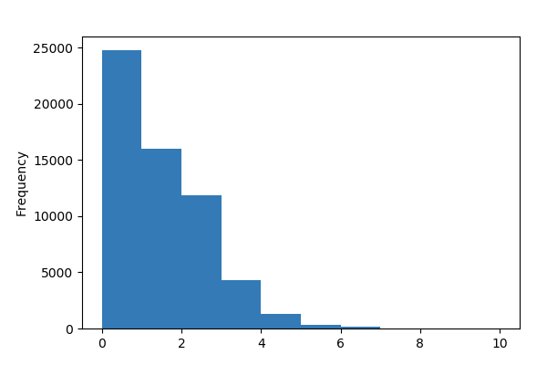

**Common Values**

| Value | Count | Frequency (%) |  |
| --- | --- | --- | --- |
| 0.0 | 24772 | 40.0% |  |
| 1.0 | 15999 | 25.8% |  |
| 2.0 | 11896 | 19.2% |  |
| 3.0 | 4307 | 6.9% |  |
| 4.0 | 1302 | 2.1% |  |
| 5.0 | 333 | 0.5% |  |
| 6.0 | 123 | 0.2% |  |
| 7.0 | 37 | 0.1% |  |
| 8.0 | 17 | 0.0% |  |
| 9.0 | 7 | 0.0% |  |
| (Missing) | 3209 | 5.2% |  |

**Extreme Values**

Minimum 5 values

| Value | Count | Frequency (%) |  |
| --- | --- | --- | --- |
| 0.0 | 24772 | 40.0% |  |
| 1.0 | 15999 | 25.8% |  |
| 2.0 | 11896 | 19.2% |  |
| 3.0 | 4307 | 6.9% |  |
| 4.0 | 1302 | 2.1% |  |

Maximum 5 values

| Value | Count | Frequency (%) |  |
| --- | --- | --- | --- |
| 6.0 | 123 | 0.2% |  |
| 7.0 | 37 | 0.1% |  |
| 8.0 | 17 | 0.0% |  |
| 9.0 | 7 | 0.0% |  |
| 10.0 | 1 | 0.0% |  |

gesta  
Numeric

| Distinct count | 27 |
| --- | --- |
| Unique (%) | 0.0% |
| Missing (%) | 4.3% |
| Missing (n) | 2662 |
| Infinite (%) | 0.0% |
| Infinite (n) | 0 |

| Mean | 2.3449 |
| --- | --- |
| Minimum | 0 |
| Maximum | 47 |
| Zeros (%) | 1.2% |

Toggle details

**Statistics**

Quantile statistics

| Minimum | 0 |
| --- | --- |
| 5-th percentile | 1 |
| Q1 | 1 |
| Median | 2 |
| Q3 | 3 |
| 95-th percentile | 5 |
| Maximum | 47 |
| Range | 47 |
| Interquartile range | 2 |

Descriptive statistics

| Standard deviation | 1.4553 |
| --- | --- |
| Coef of variation | 0.62064 |
| Kurtosis | 54.677 |
| Mean | 2.3449 |
| MAD | 1.1201 |
| Skewness | 3.2655 |
| Sum | 139150 |
| Variance | 2.118 |
| Memory size | 484.5 KiB |

**Histogram**

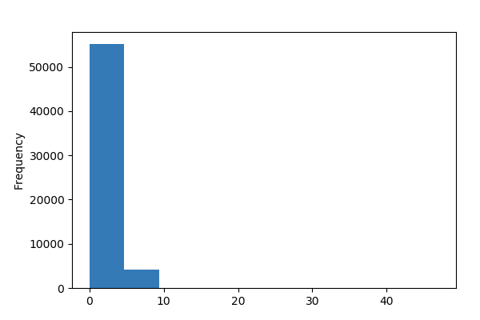

**Common Values**

| Value | Count | Frequency (%) |  |
| --- | --- | --- | --- |
| 1.0 | 19378 | 31.3% |  |
| 2.0 | 15739 | 25.4% |  |
| 3.0 | 12507 | 20.2% |  |
| 4.0 | 6757 | 10.9% |  |
| 5.0 | 2801 | 4.5% |  |
| 6.0 | 929 | 1.5% |  |
| 0.0 | 743 | 1.2% |  |
| 7.0 | 294 | 0.5% |  |
| 8.0 | 98 | 0.2% |  |
| 9.0 | 38 | 0.1% |  |
| Other values (16) | 57 | 0.1% |  |
| (Missing) | 2662 | 4.3% |  |

**Extreme Values**

Minimum 5 values

| Value | Count | Frequency (%) |  |
| --- | --- | --- | --- |
| 0.0 | 743 | 1.2% |  |
| 1.0 | 19378 | 31.3% |  |
| 2.0 | 15739 | 25.4% |  |
| 3.0 | 12507 | 20.2% |  |
| 4.0 | 6757 | 10.9% |  |

Maximum 5 values

| Value | Count | Frequency (%) |  |
| --- | --- | --- | --- |
| 32.0 | 2 | 0.0% |  |
| 33.0 | 1 | 0.0% |  |
| 41.0 | 1 | 0.0% |  |
| 42.0 | 1 | 0.0% |  |
| 47.0 | 1 | 0.0% |  |

naborto  
Numeric

| Distinct count | 11 |
| --- | --- |
| Unique (%) | 0.0% |
| Missing (%) | 6.6% |
| Missing (n) | 4115 |
| Infinite (%) | 0.0% |
| Infinite (n) | 0 |

| Mean | 0.17631 |
| --- | --- |
| Minimum | 0 |
| Maximum | 10 |
| Zeros (%) | 79.5% |

Toggle details

**Statistics**

Quantile statistics

| Minimum | 0 |
| --- | --- |
| 5-th percentile | 0 |
| Q1 | 0 |
| Median | 0 |
| Q3 | 0 |
| 95-th percentile | 1 |
| Maximum | 10 |
| Range | 10 |
| Interquartile range | 0 |

Descriptive statistics

| Standard deviation | 0.47124 |
| --- | --- |
| Coef of variation | 2.6728 |
| Kurtosis | 27.667 |
| Mean | 0.17631 |
| MAD | 0.30037 |
| Skewness | 3.8076 |
| Sum | 10206 |
| Variance | 0.22206 |
| Memory size | 484.5 KiB |

**Histogram**

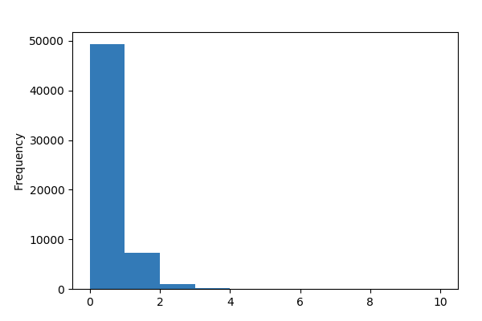

**Common Values**

| Value | Count | Frequency (%) |  |
| --- | --- | --- | --- |
| 0.0 | 49312 | 79.5% |  |
| 1.0 | 7299 | 11.8% |  |
| 2.0 | 1038 | 1.7% |  |
| 3.0 | 182 | 0.3% |  |
| 4.0 | 31 | 0.0% |  |
| 5.0 | 13 | 0.0% |  |
| 6.0 | 6 | 0.0% |  |
| 7.0 | 3 | 0.0% |  |
| 10.0 | 3 | 0.0% |  |
| 9.0 | 1 | 0.0% |  |
| (Missing) | 4115 | 6.6% |  |

**Extreme Values**

Minimum 5 values

| Value | Count | Frequency (%) |  |
| --- | --- | --- | --- |
| 0.0 | 49312 | 79.5% |  |
| 1.0 | 7299 | 11.8% |  |
| 2.0 | 1038 | 1.7% |  |
| 3.0 | 182 | 0.3% |  |
| 4.0 | 31 | 0.0% |  |

Maximum 5 values

| Value | Count | Frequency (%) |  |
| --- | --- | --- | --- |
| 5.0 | 13 | 0.0% |  |
| 6.0 | 6 | 0.0% |  |
| 7.0 | 3 | 0.0% |  |
| 9.0 | 1 | 0.0% |  |
| 10.0 | 3 | 0.0% |  |

npartos  
Numeric

| Distinct count | 12 |
| --- | --- |
| Unique (%) | 0.0% |
| Missing (%) | 6.1% |
| Missing (n) | 3763 |
| Infinite (%) | 0.0% |
| Infinite (n) | 0 |

| Mean | 0.71162 |
| --- | --- |
| Minimum | 0 |
| Maximum | 12 |
| Zeros (%) | 56.5% |

Toggle details

**Statistics**

Quantile statistics

| Minimum | 0 |
| --- | --- |
| 5-th percentile | 0 |
| Q1 | 0 |
| Median | 0 |
| Q3 | 1 |
| 95-th percentile | 3 |
| Maximum | 12 |
| Range | 12 |
| Interquartile range | 1 |

Descriptive statistics

| Standard deviation | 1.0662 |
| --- | --- |
| Coef of variation | 1.4983 |
| Kurtosis | 3.0056 |
| Mean | 0.71162 |
| MAD | 0.85634 |
| Skewness | 1.6617 |
| Sum | 41445 |
| Variance | 1.1369 |
| Memory size | 484.5 KiB |

**Histogram**

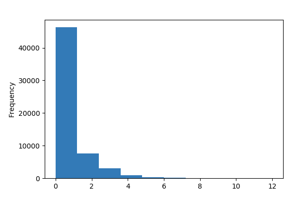

**Common Values**

| Value | Count | Frequency (%) |  |
| --- | --- | --- | --- |
| 0.0 | 35042 | 56.5% |  |
| 1.0 | 11231 | 18.1% |  |
| 2.0 | 7550 | 12.2% |  |
| 3.0 | 3071 | 5.0% |  |
| 4.0 | 978 | 1.6% |  |
| 5.0 | 263 | 0.4% |  |
| 6.0 | 77 | 0.1% |  |
| 7.0 | 18 | 0.0% |  |
| 8.0 | 8 | 0.0% |  |
| 12.0 | 1 | 0.0% |  |
| (Missing) | 3763 | 6.1% |  |

**Extreme Values**

Minimum 5 values

| Value | Count | Frequency (%) |  |
| --- | --- | --- | --- |
| 0.0 | 35042 | 56.5% |  |
| 1.0 | 11231 | 18.1% |  |
| 2.0 | 7550 | 12.2% |  |
| 3.0 | 3071 | 5.0% |  |
| 4.0 | 978 | 1.6% |  |

Maximum 5 values

| Value | Count | Frequency (%) |  |
| --- | --- | --- | --- |
| 6.0 | 77 | 0.1% |  |
| 7.0 | 18 | 0.0% |  |
| 8.0 | 8 | 0.0% |  |
| 10.0 | 1 | 0.0% |  |
| 12.0 | 1 | 0.0% |  |

ncesarea  
Numeric

| Distinct count | 8 |
| --- | --- |
| Unique (%) | 0.0% |
| Missing (%) | 6.6% |
| Missing (n) | 4099 |
| Infinite (%) | 0.0% |
| Infinite (n) | 0 |

| Mean | 0.31494 |
| --- | --- |
| Minimum | 0 |
| Maximum | 7 |
| Zeros (%) | 70.1% |

Toggle details

**Statistics**

Quantile statistics

| Minimum | 0 |
| --- | --- |
| 5-th percentile | 0 |
| Q1 | 0 |
| Median | 0 |
| Q3 | 0 |
| 95-th percentile | 2 |
| Maximum | 7 |
| Range | 7 |
| Interquartile range | 0 |

Descriptive statistics

| Standard deviation | 0.60037 |
| --- | --- |
| Coef of variation | 1.9063 |
| Kurtosis | 3.6764 |
| Mean | 0.31494 |
| MAD | 0.47277 |
| Skewness | 1.9525 |
| Sum | 18236 |
| Variance | 0.36044 |
| Memory size | 484.5 KiB |

**Histogram**

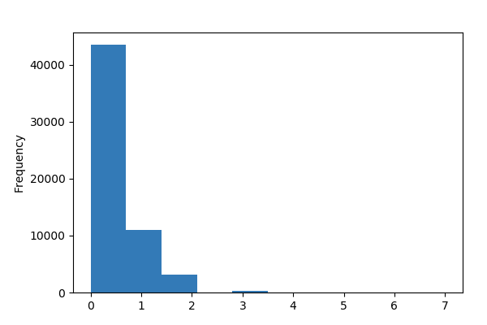

**Common Values**

| Value | Count | Frequency (%) |  |
| --- | --- | --- | --- |
| 0.0 | 43462 | 70.1% |  |
| 1.0 | 11013 | 17.8% |  |
| 2.0 | 3086 | 5.0% |  |
| 3.0 | 326 | 0.5% |  |
| 4.0 | 14 | 0.0% |  |
| 5.0 | 2 | 0.0% |  |
| 7.0 | 1 | 0.0% |  |
| (Missing) | 4099 | 6.6% |  |

**Extreme Values**

Minimum 5 values

| Value | Count | Frequency (%) |  |
| --- | --- | --- | --- |
| 0.0 | 43462 | 70.1% |  |
| 1.0 | 11013 | 17.8% |  |
| 2.0 | 3086 | 5.0% |  |
| 3.0 | 326 | 0.5% |  |
| 4.0 | 14 | 0.0% |  |

Maximum 5 values

| Value | Count | Frequency (%) |  |
| --- | --- | --- | --- |
| 2.0 | 3086 | 5.0% |  |
| 3.0 | 326 | 0.5% |  |
| 4.0 | 14 | 0.0% |  |
| 5.0 | 2 | 0.0% |  |
| 7.0 | 1 | 0.0% |  |

nile  
Numeric

| Distinct count | 9 |
| --- | --- |
| Unique (%) | 0.0% |
| Missing (%) | 20.0% |
| Missing (n) | 12405 |
| Infinite (%) | 0.0% |
| Infinite (n) | 0 |

| Mean | 0.17362 |
| --- | --- |
| Minimum | 0 |
| Maximum | 9 |
| Zeros (%) | 68.3% |

Toggle details

**Statistics**

Quantile statistics

| Minimum | 0 |
| --- | --- |
| 5-th percentile | 0 |
| Q1 | 0 |
| Median | 0 |
| Q3 | 0 |
| 95-th percentile | 1 |
| Maximum | 9 |
| Range | 9 |
| Interquartile range | 0 |

Descriptive statistics

| Standard deviation | 0.46269 |
| --- | --- |
| Coef of variation | 2.665 |
| Kurtosis | 18.271 |
| Mean | 0.17362 |
| MAD | 0.29663 |
| Skewness | 3.4004 |
| Sum | 8611 |
| Variance | 0.21409 |
| Memory size | 484.5 KiB |

**Histogram**

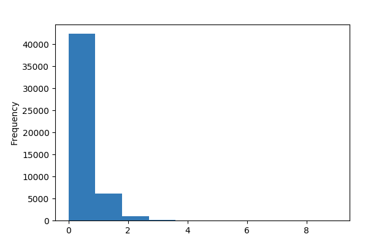

**Common Values**

| Value | Count | Frequency (%) |  |
| --- | --- | --- | --- |
| 0.0 | 42370 | 68.3% |  |
| 1.0 | 6105 | 9.8% |  |
| 2.0 | 927 | 1.5% |  |
| 3.0 | 153 | 0.2% |  |
| 4.0 | 33 | 0.1% |  |
| 5.0 | 5 | 0.0% |  |
| 6.0 | 3 | 0.0% |  |
| 9.0 | 2 | 0.0% |  |
| (Missing) | 12405 | 20.0% |  |

**Extreme Values**

Minimum 5 values

| Value | Count | Frequency (%) |  |
| --- | --- | --- | --- |
| 0.0 | 42370 | 68.3% |  |
| 1.0 | 6105 | 9.8% |  |
| 2.0 | 927 | 1.5% |  |
| 3.0 | 153 | 0.2% |  |
| 4.0 | 33 | 0.1% |  |

Maximum 5 values

| Value | Count | Frequency (%) |  |
| --- | --- | --- | --- |
| 3.0 | 153 | 0.2% |  |
| 4.0 | 33 | 0.1% |  |
| 5.0 | 5 | 0.0% |  |
| 6.0 | 3 | 0.0% |  |
| 9.0 | 2 | 0.0% |  |

consejeria  
Categorical

| Distinct count | 3 |
| --- | --- |
| Unique (%) | 0.0% |
| Missing (%) | 3.2% |
| Missing (n) | 1956 |

| si | 59424 |
| --- | --- |
| no | 623 |
| (Missing) | 1956 |

Toggle details

| Value | Count | Frequency (%) |  |
| --- | --- | --- | --- |
| si | 59424 | 95.8% |  |
| no | 623 | 1.0% |  |
| (Missing) | 1956 | 3.2% |  |

anticonceptivo  
Categorical

| Distinct count | 21 |
| --- | --- |
| Unique (%) | 0.0% |
| Missing (%) | 10.8% |
| Missing (n) | 6706 |

| ninguno | 32594 |
| --- | --- |
| condon | 15405 |
| diu | 2031 |
| Other values (17) | 5267 |
| (Missing) | 6706 |

Toggle details

| Value | Count | Frequency (%) |  |
| --- | --- | --- | --- |
| ninguno | 32594 | 52.6% |  |
| condon | 15405 | 24.8% |  |
| diu | 2031 | 3.3% |  |
| barrera | 1361 | 2.2% |  |
| anticoncepcion_de_emergencia | 1270 | 2.0% |  |
| inyeccion | 1114 | 1.8% |  |
| parche_dermico | 578 | 0.9% |  |
| implante_subdermico | 374 | 0.6% |  |
| pastillas_anticonceptivas | 312 | 0.5% |  |
| hormonal_oral | 115 | 0.2% |  |
| Other values (10) | 143 | 0.2% |  |
| (Missing) | 6706 | 10.8% |  |

c_num  
Numeric

| Distinct count | 11 |
| --- | --- |
| Unique (%) | 0.0% |
| Missing (%) | 32.7% |
| Missing (n) | 20278 |
| Infinite (%) | 0.0% |
| Infinite (n) | 0 |

| Mean | 1.684 |
| --- | --- |
| Minimum | 0 |
| Maximum | 26 |
| Zeros (%) | 0.1% |

Toggle details

**Statistics**

Quantile statistics

| Minimum | 0 |
| --- | --- |
| 5-th percentile | 1 |
| Q1 | 1 |
| Median | 2 |
| Q3 | 2 |
| 95-th percentile | 3 |
| Maximum | 26 |
| Range | 26 |
| Interquartile range | 1 |

Descriptive statistics

| Standard deviation | 0.68481 |
| --- | --- |
| Coef of variation | 0.40667 |
| Kurtosis | 83.166 |
| Mean | 1.684 |
| MAD | 0.56885 |
| Skewness | 3.0712 |
| Sum | 70263 |
| Variance | 0.46897 |
| Memory size | 484.5 KiB |

**Histogram**

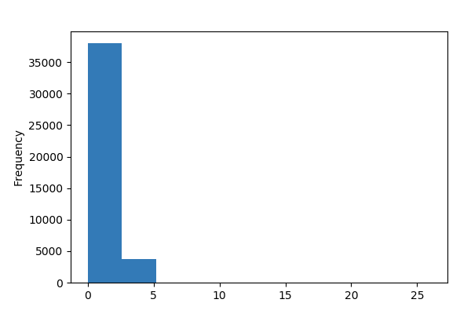

**Common Values**

| Value | Count | Frequency (%) |  |
| --- | --- | --- | --- |
| 2.0 | 20732 | 33.4% |  |
| 1.0 | 17179 | 27.7% |  |
| 3.0 | 3460 | 5.6% |  |
| 4.0 | 243 | 0.4% |  |
| 0.0 | 70 | 0.1% |  |
| 5.0 | 33 | 0.1% |  |
| 6.0 | 4 | 0.0% |  |
| 23.0 | 2 | 0.0% |  |
| 7.0 | 1 | 0.0% |  |
| 26.0 | 1 | 0.0% |  |
| (Missing) | 20278 | 32.7% |  |

**Extreme Values**

Minimum 5 values

| Value | Count | Frequency (%) |  |
| --- | --- | --- | --- |
| 0.0 | 70 | 0.1% |  |
| 1.0 | 17179 | 27.7% |  |
| 2.0 | 20732 | 33.4% |  |
| 3.0 | 3460 | 5.6% |  |
| 4.0 | 243 | 0.4% |  |

Maximum 5 values

| Value | Count | Frequency (%) |  |
| --- | --- | --- | --- |
| 5.0 | 33 | 0.1% |  |
| 6.0 | 4 | 0.0% |  |
| 7.0 | 1 | 0.0% |  |
| 23.0 | 2 | 0.0% |  |
| 26.0 | 1 | 0.0% |  |

motiles  
Categorical

| Distinct count | 14 |
| --- | --- |
| Unique (%) | 0.0% |
| Missing (%) | 1.8% |
| Missing (n) | 1088 |

| interrupcion_voluntaria | 60414 |
| --- | --- |
| no_lo_desea_en_este_momento | 171 |
| falta_de_recursos_economicos | 91 |
| Other values (10) | 239 |
| (Missing) | 1088 |

Toggle details

| Value | Count | Frequency (%) |  |
| --- | --- | --- | --- |
| interrupcion_voluntaria | 60414 | 97.4% |  |
| no_lo_desea_en_este_momento | 171 | 0.3% |  |
| falta_de_recursos_economicos | 91 | 0.1% |  |
| no_especificado | 78 | 0.1% |  |
| ya_tiene_muchos_hijos | 43 | 0.1% |  |
| no_quiere_interrumpir_sus_estudios/trabajo | 31 | 0.0% |  |
| motivos_de_salud | 22 | 0.0% |  |
| otro | 19 | 0.0% |  |
| violacion | 16 | 0.0% |  |
| problemas_con_pareja | 13 | 0.0% |  |
| Other values (3) | 17 | 0.0% |  |
| (Missing) | 1088 | 1.8% |  |

h_fingreso  
Categorical

| Distinct count | 583 |
| --- | --- |
| Unique (%) | 0.9% |
| Missing (%) | 12.2% |
| Missing (n) | 7537 |

| NE | 49140 |
| --- | --- |
| 16/01/19 | 27 |
| 01/10/18 | 26 |
| Other values (579) | 5273 |
| (Missing) | 7537 |

Toggle details

| Value | Count | Frequency (%) |  |
| --- | --- | --- | --- |
| NE | 49140 | 79.3% |  |
| 16/01/19 | 27 | 0.0% |  |
| 01/10/18 | 26 | 0.0% |  |
| 22/08/18 | 26 | 0.0% |  |
| 15/05/19 | 25 | 0.0% |  |
| 11/02/19 | 23 | 0.0% |  |
| 09/11/18 | 22 | 0.0% |  |
| 24/08/18 | 22 | 0.0% |  |
| 13/07/16 | 21 | 0.0% |  |
| 11/09/18 | 21 | 0.0% |  |
| Other values (572) | 5113 | 8.2% |  |
| (Missing) | 7537 | 12.2% |  |

desc_servicio  
Categorical

| Distinct count | 9 |
| --- | --- |
| Unique (%) | 0.0% |
| Missing (%) | 6.8% |
| Missing (n) | 4215 |

| ile | 47760 |
| --- | --- |
| gineco_obstetricia | 5576 |
| consulta_externa | 2590 |
| Other values (5) | 1862 |
| (Missing) | 4215 |

Toggle details

| Value | Count | Frequency (%) |  |
| --- | --- | --- | --- |
| ile | 47760 | 77.0% |  |
| gineco_obstetricia | 5576 | 9.0% |  |
| consulta_externa | 2590 | 4.2% |  |
| salud_reproductiva | 1590 | 2.6% |  |
| enfermeria | 169 | 0.3% |  |
| cirugia_ambulatoria | 91 | 0.1% |  |
| tococirugia | 8 | 0.0% |  |
| administracion | 4 | 0.0% |  |
| (Missing) | 4215 | 6.8% |  |

p_semgest  
Numeric

| Distinct count | 14 |
| --- | --- |
| Unique (%) | 0.0% |
| Missing (%) | 0.0% |
| Missing (n) | 29 |
| Infinite (%) | 0.0% |
| Infinite (n) | 0 |

| Mean | 6.8425 |
| --- | --- |
| Minimum | 0 |
| Maximum | 12 |
| Zeros (%) | 0.8% |

Toggle details

**Statistics**

Quantile statistics

| Minimum | 0 |
| --- | --- |
| 5-th percentile | 4 |
| Q1 | 5 |
| Median | 7 |
| Q3 | 8 |
| 95-th percentile | 11 |
| Maximum | 12 |
| Range | 12 |
| Interquartile range | 3 |

Descriptive statistics

| Standard deviation | 2.1784 |
| --- | --- |
| Coef of variation | 0.31836 |
| Kurtosis | 0.24599 |
| Mean | 6.8425 |
| MAD | 1.7048 |
| Skewness | -0.05814 |
| Sum | 424060 |
| Variance | 4.7453 |
| Memory size | 484.5 KiB |

**Histogram**

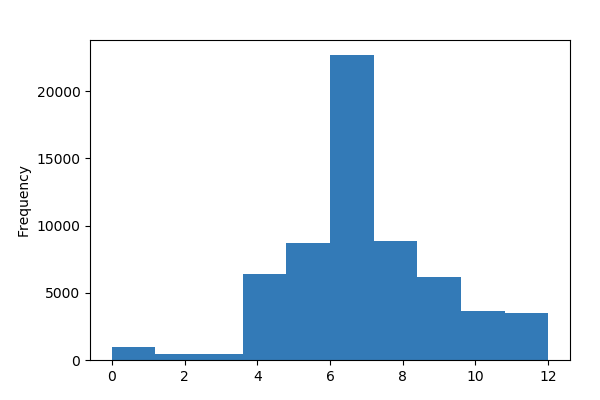

**Common Values**

| Value | Count | Frequency (%) |  |
| --- | --- | --- | --- |
| 7.0 | 13031 | 21.0% |  |
| 6.0 | 9646 | 15.6% |  |
| 8.0 | 8855 | 14.3% |  |
| 5.0 | 8735 | 14.1% |  |
| 4.0 | 6412 | 10.3% |  |
| 9.0 | 6198 | 10.0% |  |
| 10.0 | 3632 | 5.9% |  |
| 11.0 | 2542 | 4.1% |  |
| 12.0 | 992 | 1.6% |  |
| 0.0 | 501 | 0.8% |  |
| Other values (3) | 1430 | 2.3% |  |

**Extreme Values**

Minimum 5 values

| Value | Count | Frequency (%) |  |
| --- | --- | --- | --- |
| 0.0 | 501 | 0.8% |  |
| 1.0 | 493 | 0.8% |  |
| 2.0 | 470 | 0.8% |  |
| 3.0 | 467 | 0.8% |  |
| 4.0 | 6412 | 10.3% |  |

Maximum 5 values

| Value | Count | Frequency (%) |  |
| --- | --- | --- | --- |
| 8.0 | 8855 | 14.3% |  |
| 9.0 | 6198 | 10.0% |  |
| 10.0 | 3632 | 5.9% |  |
| 11.0 | 2542 | 4.1% |  |
| 12.0 | 992 | 1.6% |  |

p_diasgesta  
Numeric

| Distinct count | 83 |
| --- | --- |
| Unique (%) | 0.1% |
| Missing (%) | 21.6% |
| Missing (n) | 13401 |
| Infinite (%) | 0.0% |
| Infinite (n) | 0 |

| Mean | 5.1793 |
| --- | --- |
| Minimum | 0 |
| Maximum | 94 |
| Zeros (%) | 6.5% |

Toggle details

**Statistics**

Quantile statistics

| Minimum | 0 |
| --- | --- |
| 5-th percentile | 0 |
| Q1 | 2 |
| Median | 3 |
| Q3 | 5 |
| 95-th percentile | 6 |
| Maximum | 94 |
| Range | 94 |
| Interquartile range | 3 |

Descriptive statistics

| Standard deviation | 10.428 |
| --- | --- |
| Coef of variation | 2.0133 |
| Kurtosis | 26.491 |
| Mean | 5.1793 |
| MAD | 4.1063 |
| Skewness | 5.0426 |
| Sum | 251730 |
| Variance | 108.73 |
| Memory size | 484.5 KiB |

**Histogram**

[3 more figures not shown]

Sample

|  | ano | mes | cve_hospital | fingreso | autoref | edocivil_descripcion | edad | desc_derechohab | nivel_edu | ocupacion | religion | parentesco | entidad | alc_o_municipio | menarca | fsexual | fmenstrua | sememb | nhijos | gesta | naborto | npartos | ncesarea | nile | consejeria | anticonceptivo | c_num | motiles | h_fingreso | … |
| --- | --- | --- | --- | --- | --- | --- | --- | --- | --- | --- | --- | --- | --- | --- | --- | --- | --- | --- | --- | --- | --- | --- | --- | --- | --- | --- | --- | --- | --- | --- |
| 0 | 2016 | enero | 10 | 12/01/16 | autorreferida | soltera | 34 | ninguna | primaria_completa | desempleada | ninguna | amiga | estado_de_mexico | NaN | 11.0 | 17.0 | 16/11/15 | 7.0 | 1.0 | 3.0 | 0.0 | 0.0 | 1.0 | 1.0 | si | anticoncepcion_de_emergencia | 2.0 | interrupcion_voluntaria | NE | … |
| 1 | 2016 | abril | 1 | 25/04/16 | no | union_libre | 27 | ninguna | licenciatura_completa | mesera | ninguna | pareja | ciudad_de_mexico | iztapalapa | 11.0 | 18.0 | 25/02/16 | 8.4 | 1.0 | 3.0 | 0.0 | 1.0 | 1.0 | 0.0 | si | condon | NaN | interrupcion_voluntaria | 25/04/16 | … |
| 2 | 2018 | julio | 4 | 11/07/18 | NaN | soltera | 29 | ninguna | secundaria_completa | trabajadora_del_sector_publico | ninguna | NaN | estado_de_mexico | nezahualcoyotl | 11.0 | 15.0 | 18/05/18 | 7.0 | 3.0 | 4.0 | 0.0 | 3.0 | 0.0 | 0.0 | si | diu | 2.0 | interrupcion_voluntaria | NE | … |
| 3 | 2016 | enero | 10 | 07/01/16 | autorreferida | casada | 33 | ninguna | preparatoria_completa | ama_de_casa | catolica | conyuge | estado_de_mexico | coacalco | 15.0 | 17.0 | 16/11/15 | 7.4 | 2.0 | 4.0 | 1.0 | 2.0 | 0.0 | 0.0 | si | ninguno | 2.0 | interrupcion_voluntaria | NE | … |
| 4 | 2018 | agosto | 7 | NaN | no | union_libre | 23 | n/e | preparatoria_completa | NaN | catolica | NaN | ciudad_de_mexico | alvaro_obregon | 12.0 | 16.0 | NaN | NaN | 1.0 | 2.0 | 0.0 | 1.0 | 0.0 | 0.0 | si | condon | 2.0 | interrupcion_voluntaria | 24/08/18 | … |

```python
profile = pandas_profiling.ProfileReport(df)
profile
```

## Data profiling

Luego de realizar el *data profiling* se identificó que varias variables presentan un alto porcentaje de *missing values*, razón por la cual no se utilizarán para el análisis. En particular, se utilizó un umbral del 10%.

A continuación se listan dichas variables junto con el número de observaciones faltantes y el porcentaje del total que representan.

- `autoref`: tiene 45129 datos faltantes (72.8%)
- `c_num`: tiene 20278 datos faltantes (32.7%)
- `desc_derechohab`: 7041 (11.4%)
- `fmenstrua`: tiene 6704 datos faltantes (10.8%)
- `h_fingreso`: tiene 7537 datos faltantes (12.2%)
- `nile`: tiene 12405 datos faltantes (20.0%)
- `p_consent`: tiene 44147 datos faltantes (71.2%)
- `p_diasgesta`: tiene 13401 datos faltantes (21.6%)
- `panticoncep`: tiene 16804 datos faltantes (27.1%)
- `parentesco`: tiene 41840 datos faltantes (67.5%)
- `s_complica`: tiene 29235 datos faltantes (47.2%)
- `ocupacion`: tiene 7721 datos faltantes (12.5%)
- `anticonceptivo`: tiene 6706 datos faltantes (10.8%)

Otro criterio utilizado para descartar la utilización de algunas variables fue su alta cardinalidad. En particular, el umbral definido fue una cardinalidad de 100. A continuación se listan las variables eliminadas bajo dicho criterio y su respectiva cardinalidad:

- `alc_o_municipio`: con cardinalidad 497
- `religion`: con cardinalidad 1820
- `motiles`: con cardinalidad 1088

Adicionalmente, dado que se busca predecir una variable binaria referente a la edad de la persona a quien que se realiza la intervención. Se excluyeron variables que se refieren netamente a la tempoalidad en que se se realizó la intervención:

- `ano`
- `mes`
- `fingreso`

De igual forma, se elimina la variable `edad` en la medida que la variable de respuesta es una transformación de la misma.

```python
vars_to_remove = ["autoref",
                  "c_num",
                  "desc_derechohab",
                  "fmenstrua",
                  "h_fingreso",
                  "nile",
                  "p_consent",
                  "p_diasgesta",
                  "panticoncep",
                  "parentesco",
                  "s_complica",
                  "alc_o_municipio",
                  "fingreso",
                  "ocupacion",
                  "anticonceptivo",
                  "ano",
                  "mes",
                  "edad",
                  "entidad", # alta cardinalidad
                  "procile", # alta cardinalidad
                  "nivel_edu", # alta cardinalidad
                  "cve_hospital", # alta cardinalidad
                  "religion", # alta cardinalidad
                  "motiles"] # alta cardinalidad

for var in vars_to_remove:
    df = cd.eliminar_col(df, var)

df.head()
```

|  | edocivil_descripcion | menarca | fsexual | sememb | nhijos | gesta | naborto | npartos | ncesarea | consejeria | desc_servicio | p_semgest | mayor_23 |
| --- | --- | --- | --- | --- | --- | --- | --- | --- | --- | --- | --- | --- | --- |
| 0 | soltera | 11.0 | 17.0 | 7.0 | 1.0 | 3.0 | 0.0 | 0.0 | 1.0 | si | salud_reproductiva | 0.0 | 1 |
| 1 | union_libre | 11.0 | 18.0 | 8.4 | 1.0 | 3.0 | 0.0 | 1.0 | 1.0 | si | ile | 11.0 | 1 |
| 2 | soltera | 11.0 | 15.0 | 7.0 | 3.0 | 4.0 | 0.0 | 3.0 | 0.0 | si | ile | 7.0 | 1 |
| 3 | casada | 15.0 | 17.0 | 7.4 | 2.0 | 4.0 | 1.0 | 2.0 | 0.0 | si | salud_reproductiva | 4.0 | 1 |
| 4 | union_libre | 12.0 | 16.0 | NaN | 1.0 | 2.0 | 0.0 | 1.0 | 0.0 | si | gineco_obstetricia | 7.0 | 0 |

Una vez definidas las variables con las que se realizará el análisis estadístico, a continuación se procede a realizar el analisis exploratorio de los datos.

```python
df.info()
```

```
<class 'pandas.core.frame.DataFrame'>
RangeIndex: 62003 entries, 0 to 62002
Data columns (total 13 columns):
edocivil_descripcion    61887 non-null category
menarca                 59114 non-null float64
fsexual                 57750 non-null float64
sememb                  58403 non-null float64
nhijos                  58794 non-null float64
gesta                   59341 non-null float64
naborto                 57888 non-null float64
npartos                 58240 non-null float64
ncesarea                57904 non-null float64
consejeria              60047 non-null category
desc_servicio           57788 non-null category
p_semgest               61974 non-null float64
mayor_23                62003 non-null int64
dtypes: category(3), float64(9), int64(1)
memory usage: 4.9 MB
```

### 2. Graphical Exploratory Data Analysis (EDA)

Decidir las 5 mejores cosas que reportar:

1. Matriz de correlaciones entre numéricas
2. Tal vez gráficas de conteos por paneles que dependen de si es o no mayor de 23 años

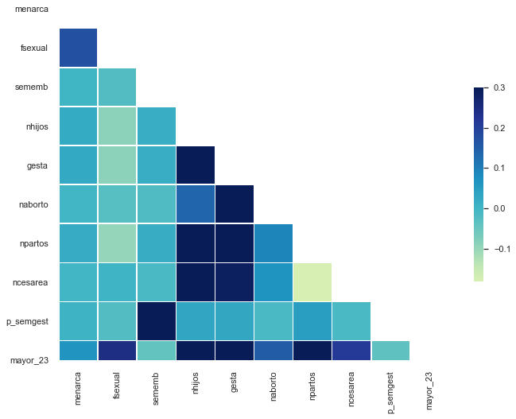

```python
import seaborn as sns

corr_df=df
var=["edocivil_descripcion","consejeria","desc_servicio"]
corr_df = cd.eliminar_col(corr_df, var)


sns.set(style="white")
corr = df.corr(method = "pearson") # se computa la correlación de las variables

    # Generate a mask for the upper triangle
mask = np.zeros_like(corr, dtype=np.bool)
mask[np.triu_indices_from(mask)] = True

    # Set up the matplotlib figure
f, ax = plt.subplots(figsize=(11, 9))

    # Draw the heatmap with the mask and correct aspect ratio
sns.heatmap(corr, mask=mask, cmap="YlGnBu", vmax=.3, center=0,
            square=True, linewidths=.5, cbar_kws={"shrink": .5})
```

```python
from sklearn.feature_selection import RFE, chi2, f_regression, f_classif
from sklearn.impute import SimpleImputer
from sklearn.linear_model import LogisticRegression
# Selección de datos
from sklearn.model_selection import train_test_split
from sklearn.model_selection import GridSearchCV
```

## Parte II

**Acá inicia el código para incluir después como pipeline**

```python
# definir variable de respuesta
output_var = df['mayor_23']
# definir matriz de features
input_vars = df.drop('mayor_23', axis=1)
```

### ColumnTransformer

Utilizaremos el `ColumnTransformer` de `sklearn` para realizar todos los cambios que queremos hacer a las variables del dataset.

Para las variables categóricas listadas a continuación se imputaron los valores faltantes con sus respectivos valores más frecuentes. A continuación se muestra la variable con el número y porcentaje de inputaciones realizadas.

```python
from sklearn.compose import ColumnTransformer
from sklearn.preprocessing import MinMaxScaler, OneHotEncoder, LabelEncoder, QuantileTransformer
from sklearn.impute import SimpleImputer
# imputar a los valores faltantes el valor más frecuente
col_names = input_vars.columns
na_imputer = SimpleImputer(missing_values=np.nan, strategy='most_frequent')
na_imputer = na_imputer.fit(input_vars)
input_vars = na_imputer.transform(input_vars)
# convertir de nuevo de Dataframe
input_vars = pd.DataFrame(input_vars)
input_vars.columns = col_names
input_vars.isna().sum()
```

```
edocivil_descripcion    0
menarca                 0
fsexual                 0
sememb                  0
nhijos                  0
gesta                   0
naborto                 0
npartos                 0
ncesarea                0
consejeria              0
desc_servicio           0
p_semgest               0
dtype: int64
```

### Transformaciones

Para poder manipular las variables categóricas, es necesario realizar la transformación de las mismas a tipo numérico. Para lograr este objetivo, se utiliza primero el método de *label encoding* y luego el método de *One hot encoding*.

```python
#label encoder
from sklearn.preprocessing import LabelEncoder

vars_to_le = ["edocivil_descripcion",
             "desc_servicio",
             "consejeria"]
le = LabelEncoder()
for var in vars_to_le:
    input_vars[var] = le.fit_transform(input_vars[var])
    lab_procile=le.classes_

input_vars.head()
```

|  | edocivil_descripcion | menarca | fsexual | sememb | nhijos | gesta | naborto | npartos | ncesarea | consejeria | desc_servicio | p_semgest |
| --- | --- | --- | --- | --- | --- | --- | --- | --- | --- | --- | --- | --- |
| 0 | 4 | 11 | 17 | 7 | 1 | 3 | 0 | 0 | 1 | 1 | 6 | 0 |
| 1 | 5 | 11 | 18 | 8.4 | 1 | 3 | 0 | 1 | 1 | 1 | 5 | 11 |
| 2 | 4 | 11 | 15 | 7 | 3 | 4 | 0 | 3 | 0 | 1 | 5 | 7 |
| 3 | 0 | 15 | 17 | 7.4 | 2 | 4 | 1 | 2 | 0 | 1 | 6 | 4 |
| 4 | 5 | 12 | 16 | 7 | 1 | 2 | 0 | 1 | 0 | 1 | 4 | 7 |

One hot enconding

```python
# oneHot encoder
from sklearn.preprocessing import OneHotEncoder
ohe = OneHotEncoder(categories='auto', drop="first") # eliminar la primera columna

X_edocivil_descripcion = ohe.fit_transform(input_vars.edocivil_descripcion.values.reshape(-1,1)).toarray()
X_desc_servicio = ohe.fit_transform(input_vars.desc_servicio.values.reshape(-1,1)).toarray()
X_consejeria = ohe.fit_transform(input_vars.consejeria.values.reshape(-1,1)).toarray()
# df con ohe nombres numerados
dfOneHot_edocivil_descripcion = pd.DataFrame(X_edocivil_descripcion, columns = ["edocivil_descripcion_"+str(int(i)) for i in range(X_edocivil_descripcion.shape[1])])
input_vars = pd.concat([input_vars, dfOneHot_edocivil_descripcion], axis=1)
dfOneHot_desc_servicio = pd.DataFrame(X_desc_servicio, columns = ["desc_servicio_"+str(int(i)) for i in range(X_desc_servicio.shape[1])])
input_vars = pd.concat([input_vars, dfOneHot_desc_servicio], axis=1)
dfOneHot_consejeria = pd.DataFrame(X_consejeria, columns = ["consejeria_"+str(int(i)) for i in range(X_consejeria.shape[1])])
input_vars = pd.concat([input_vars, dfOneHot_consejeria], axis=1)
input_vars.head()
```

|  | edocivil_descripcion | menarca | fsexual | sememb | nhijos | gesta | naborto | npartos | ncesarea | consejeria | desc_servicio | p_semgest | edocivil_descripcion_0 | edocivil_descripcion_1 | edocivil_descripcion_2 | edocivil_descripcion_3 | edocivil_descripcion_4 | edocivil_descripcion_5 | desc_servicio_0 | desc_servicio_1 | desc_servicio_2 | desc_servicio_3 | desc_servicio_4 | desc_servicio_5 | desc_servicio_6 | consejeria_0 |
| --- | --- | --- | --- | --- | --- | --- | --- | --- | --- | --- | --- | --- | --- | --- | --- | --- | --- | --- | --- | --- | --- | --- | --- | --- | --- | --- |
| 0 | 4 | 11 | 17 | 7 | 1 | 3 | 0 | 0 | 1 | 1 | 6 | 0 | 0.0 | 0.0 | 0.0 | 1.0 | 0.0 | 0.0 | 0.0 | 0.0 | 0.0 | 0.0 | 0.0 | 1.0 | 0.0 | 1.0 |
| 1 | 5 | 11 | 18 | 8.4 | 1 | 3 | 0 | 1 | 1 | 1 | 5 | 11 | 0.0 | 0.0 | 0.0 | 0.0 | 1.0 | 0.0 | 0.0 | 0.0 | 0.0 | 0.0 | 1.0 | 0.0 | 0.0 | 1.0 |
| 2 | 4 | 11 | 15 | 7 | 3 | 4 | 0 | 3 | 0 | 1 | 5 | 7 | 0.0 | 0.0 | 0.0 | 1.0 | 0.0 | 0.0 | 0.0 | 0.0 | 0.0 | 0.0 | 1.0 | 0.0 | 0.0 | 1.0 |
| 3 | 0 | 15 | 17 | 7.4 | 2 | 4 | 1 | 2 | 0 | 1 | 6 | 4 | 0.0 | 0.0 | 0.0 | 0.0 | 0.0 | 0.0 | 0.0 | 0.0 | 0.0 | 0.0 | 0.0 | 1.0 | 0.0 | 1.0 |
| 4 | 5 | 12 | 16 | 7 | 1 | 2 | 0 | 1 | 0 | 1 | 4 | 7 | 0.0 | 0.0 | 0.0 | 0.0 | 1.0 | 0.0 | 0.0 | 0.0 | 0.0 | 1.0 | 0.0 | 0.0 | 0.0 | 1.0 |

```python
# se eliminan las variables categóricas originales
for var in vars_to_le:
    input_vars = input_vars.drop(var,axis=1)
input_vars.head(1)
```

|  | menarca | fsexual | sememb | nhijos | gesta | naborto | npartos | ncesarea | p_semgest | edocivil_descripcion_0 | edocivil_descripcion_1 | edocivil_descripcion_2 | edocivil_descripcion_3 | edocivil_descripcion_4 | edocivil_descripcion_5 | desc_servicio_0 | desc_servicio_1 | desc_servicio_2 | desc_servicio_3 | desc_servicio_4 | desc_servicio_5 | desc_servicio_6 | consejeria_0 |
| --- | --- | --- | --- | --- | --- | --- | --- | --- | --- | --- | --- | --- | --- | --- | --- | --- | --- | --- | --- | --- | --- | --- | --- |
| 0 | 11 | 17 | 7 | 1 | 3 | 0 | 0 | 1 | 0 | 0.0 | 0.0 | 0.0 | 1.0 | 0.0 | 0.0 | 0.0 | 0.0 | 0.0 | 0.0 | 0.0 | 1.0 | 0.0 | 1.0 |

### Feature selection

Con el fin de seleccionar las características más relevantes para explicar la variable de respuesta, a continuación se realizan varios ejercicio de *feature selection* con el fin de determinar los features más importantes. Para la implementación se utilizaron varios métodos de `sklearn`.

**I. Propiedades de la distribución** Inicialmente, se realiza un filtrado basado en las propiedades de las distribuciones. En particular, se utiliza el método `VarianceThreshold` de `sklearn`.

```python
# vector con nombres de las características
columnsNamesArr = input_vars.columns.values
```

```python
from sklearn.feature_selection import VarianceThreshold
variance_threshold = VarianceThreshold(threshold=0.1)
variance_threshold.fit(input_vars)
```

```
VarianceThreshold(threshold=0.1)
```

**II. Eliminación recursiva de variables***

- `menarca`
- `fsexual`
- `sememb`
- `nhijos`
- `gesta`

```python
from sklearn.feature_selection import RFE
from sklearn.linear_model import LogisticRegression
# crear un objeto con tipo de modelo
model = LogisticRegression(solver='lbfgs', max_iter=1000) #solver='lbfgs',
# identificar las variables más relevantes
rfe = RFE(model, 5)
rfe = rfe.fit(input_vars, output_var)
# resumen de los atributos seleccionados
rfe_support = rfe.support_

print("Los 5 features más relevantes por RFE son:")
print("="*43)
count = 0
for elements in rfe_support:
    if elements==True:
        print(columnsNamesArr[count])
        count+= 1
    else:
        None
```

```
Los 5 features más relevantes por RFE son:
===========================================
menarca
fsexual
sememb
nhijos
gesta
```

**Usando modelos**

**Random forest**

Con este modelo, las variables seleccionadas fueron:

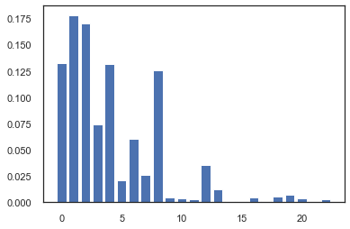

```
Los 5 features más relevantes por Random Forest son:
====================================================
menarca
fsexual
sememb
nhijos
gesta
```

```python
from sklearn.ensemble import RandomForestClassifier

rfc = RandomForestClassifier(random_state = 0, n_jobs = -1)
rfc.fit(input_vars, output_var)
positions= range(rfc.feature_importances_.shape[0])
plt.bar(positions, rfc.feature_importances_)
rfc_fimp = rfc.feature_importances_
plt.show()
positions_rfc = np.where(rfc_fimp>=0.125,True,False)

print("Los 5 features más relevantes por Random Forest son:")
print("="*52)
count = 0
for elements in positions_rfc:
    if elements==True:
        print(columnsNamesArr[count])
        count+= 1
    else:
        None
```

**Extra Trees**

Con este criterio, las variables seleccionadas fueron:

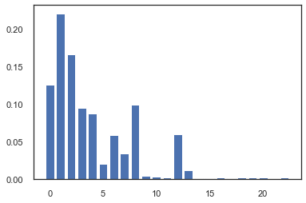

```
Los 5 features más relevantes por Extra Trees son:
====================================================
menarca
fsexual
sememb
nhijos
gesta
```

```python
import matplotlib.pyplot as plt
from sklearn.ensemble import ExtraTreesClassifier
# fit an Extra Trees model to the data
etc = ExtraTreesClassifier()
etc.fit(input_vars, output_var)
# display the relative importance of each attribute
#print(model.feature_importances_)
positions= range(etc.feature_importances_.shape[0])
plt.bar(positions, etc.feature_importances_)
etc_fimp = etc.feature_importances_
plt.show()
positions_etc = np.where(etc_fimp>=0.09,True,False)

print("Los 5 features más relevantes por Extra Trees son:")
print("="*52)
count = 0
for elements in positions_etc:
    if elements==True:
        print(columnsNamesArr[count])
        count+= 1
    else:
        None
```

```python
features = ["menarca", "fsexual", "sememb", "nhijos", "gesta"]
X = input_vars[features]
y = output_var
X.isnull().sum()
```

```
menarca    0
fsexual    0
sememb     0
nhijos     0
gesta      0
dtype: int64
```

# Model selection

**Hiperparameter tunning**

```python
from sklearn.model_selection import train_test_split, GridSearchCV
from sklearn.ensemble import RandomForestClassifier
```

```python
#estaban en el magic loop. Ver cuales si funcionan

from sklearn.metrics import roc_curve, auc, confusion_matrix
from sklearn.model_selection import cross_validate, train_test_split, GridSearchCV, ParameterGrid
from sklearn.ensemble import RandomForestClassifier, GradientBoostingClassifier, AdaBoostClassifier
from sklearn.linear_model import SGDClassifier
from sklearn.tree import DecisionTreeClassifier
from sklearn.metrics import *
from sklearn.preprocessing import StandardScaler
from sklearn import preprocessing, svm, metrics, tree, decomposition
```

**Nota: en clase hicimos una anotación sobre entrenamiento, y selección del modelo)** Repensarlo a ver si tiene algo que ver.

### Magic loop

Tomado de las [notas de clase](https://github.com/ITAM-DS/introduction-to-data-science-2019/blob/master/6_models.md) y del repositorio de [Rayid Ghani](https://github.com/rayidghani/magicloops) y de [Joshua Gary](https://github.com/jmausolf/magicloops). En esta sección se incorpora un algoritmo *magic loop* tomado de los anteriores repositorios, y se realiza una adaptación que incluye el hiperparameter tunning con los siguientes modelos:

- Random Forest (`RandomForest`)
- Árbol (`DecisionTreeClassifier`)
- XGBoost (`GradientBoostingClassifier`)
- AdaBoost (`AdaBoostClassifier`)

En particular, este `MagicLoop` busca probar diferentes configuraciones de hiperparámetros para los algoritmos citados arriba, con el fin de determinar qué combinaciones resultan en su muejor desempeño, para cada uno.

La implementación seleccionada permite implementar diferentes métricas de ajuste de los modelos. Sin embargo, es clave especificar que es de vital importancia determinar el cause de nuestro problema, para saber qué métrica nos resulta más útil y así poder elegir un modelo. Más adelante justificamos la elección del *F1-Score* (el cual combina *precision* y *recall* ) como criterio de elección del mejor modelo.

**Definición de los posibles hiperparámetros de los modelos**

```python
def define_hyper_params():
    """
    Esta función define el parameter grid para los distintos clasificadores.
    Es utilizada posteriormente para que se realicen las respectivas
    evaluaciones con las congifuraciones definidas.
    """
    classifiers = {
        'RF': RandomForestClassifier(n_estimators=50, n_jobs=-1),
        'DT': DecisionTreeClassifier(),
        'GB': GradientBoostingClassifier(learning_rate=0.05, subsample=0.5, max_depth=6, n_estimators=10),
        'AB': AdaBoostClassifier(DecisionTreeClassifier(max_depth=1), algorithm="SAMME", n_estimators=200)
            }

    #Aqui definimos los parametros que queremos checar en el magic loop
    grid = {
        'RF':{'n_estimators': [1,10,100,1000], 'max_depth': [1,10,30,50], 'max_features': ['sqrt','log2'],'min_samples_split': [2,5,10], 'n_jobs':[-1]},
        'DT': {'criterion': ['gini', 'entropy'], 'max_depth': [1,10,30,50], 'max_features': [None],'min_samples_split': [2,5,10]},
        'GB': {'n_estimators': [1,10,100,1000], 'learning_rate' : [0.001,0.1,0.5],'subsample' : [0.1,.5,.7,1], 'max_depth': [5,10,20]},
        'AB': { 'algorithm': ['SAMME', 'SAMME.R'], 'n_estimators': [1]}
            }
    return classifiers, grid
```

**`MagiLoop`**

Come especificó anteriormente, el algoritmo implementado toma como criterio de ordenamiento entre modelos y sus respectivos hiperparámetros el `F1-score`, sin embargo también podrían ser métricas como `precision`o `recall`.

**¿Qué score utilizar para clasificar los modelos?**

**¿Qué deberíamos optimizar aquí: Precision o recall? Justifica**

En particular, para este caso se decidió utilizar la métrica de `F1-score` en la medida que no se ha planteado un objetivo final para las predicciones hechas con el modelo. En particular, si tuvieramos un problema materializable y supieramos quién y qué tipo de de decisión va a tomar con respecto a las predicciones, podríamos decidir qué nos resulta más costoso, si tener un mayor porcentaje de éxito de personas predichas con 23 años o más sobre predicciones realizadas( *presicion* ) o si tener un mayor porercentaje de predicciones correctas sobre el total de inviduos que en efecto tienen 23 años o más. En este sentido, el estadístico "F1-score" nos ayuda a plantear una medida que agrega tanto *recall* como *precision* (como media armónica), con el fin de establecer una étrica que balancee los dos objetivos mencionados.

Para ilustrar esto se podría plantear un ejemplo. Dado que son personas menores a 23 años las que presentan la mayor cantidad de población que se realiza intervenciones de embarazo legal en la muestra, podríamos querer focalizar una campaña hacia dicho grupo que incentive conductas de planificación que eviten llegar al aborto. En esta medida, se podrían analizar las features de la población (menarca, fsexual, sememb, nhijos) y realizar predicción para dicha población.

Suponga un escenario donde somos el gobierno y queremos disminuir el número de abortos legales en la población, porque, por ejemplo, dichos procedimientos son financiados y/o subsidiados con recursos públicos. Dado lo anterior, para el Gobierno probablemente si sea relevante que el número de equivocaciones sobre el total de personas sea bajo (recall) en la medida que implica una cuantía importante de costos no focalizar bien los recursos de la campaña a la población objetivo, y además (suponiendo que la campaña es efectiva), el hecho de no equivocarse en la predicción ayudaría a ahorrar una gran cantidad de recursos que se destinan al subsidio de intervenciones de interrupción del embarazo. Este tipo de ejemplo genera importantes implicaciones éticas, que se discuten en la tabla de anexos, en la medida que afecta de forma trascendental la vida de varias personas. Este es un caso done recall tiene mayor importancia.

Alternativamente, suponga un escenario en el cual somos una persona menor de 23 años que no tiene los recursos para entrar en programas de acompañamiento y financiación en planificación sexual. En este sentido, nos interesaría que el modelo no se equivoque sobre el total de la población objetivo.

Por otro lado, suponga que somos una farmaceutica que quiere dar a probar un medicamento de planificación a población menor a 23 años con el fin de evaluar su desempeño. El medicamento es costoso, y los recursos son escasos. Para emplear dichos recursos de forma eficiente, la emppresa probablemente quiera que el modelo se equivoque el menor número de veces posibles, para que puedan entregar su producto de forma adecuada (precision).

En este estudio, no tenemos definido qué agente somos, ni tampoco hemos establecido aún nuestros recursos y/o si quieremos tener un target exhaustivo sobre un total de la población. Es por ello que decidimos adoptar la métrica del *F1-score* , que es una media armónica entre *precision y recall*. En este sentido, balanceamos el tradeoff entre estos dos objetivos cuando queremos seleccionar nuestros modelos.

```python
def magic_loop_GS(models_to_run, clfs, grid, X, y):

    #crea df para ir guardando las calificaciones del modelo y el parametro
    d={'modelo':[""],"params":[""],"f1":[0]}
    model_hyperparmeter=pd.DataFrame(data=d)

    X_train, X_test, y_train, y_test = train_test_split(X, y)
    for index, clf in enumerate([clfs[x] for x in models_to_run]):
        hyper_param_grid = grid[models_to_run[index]]

        grid_search = GridSearchCV(clf,
                           hyper_param_grid,
                           scoring = 'f1',
                           cv = 5,
                           n_jobs = -1,
                           verbose = 5)

        grid_search.fit(X, y)

        #de los valores posibles que pusimos en el grid, cuáles fueron los mejores
        best_param=[grid_search.best_params_]

        #mejor score asociado a los modelos generados con los diferentes hiperparametros
        #corresponde al promedio de los scores generados con los cv
        best_score=grid_search.best_score_

        d={'modelo':models_to_run[index],"params":best_param,"f1":best_score}
        model_new=pd.DataFrame(data=d)
        model_hyperparmeter=model_hyperparmeter.append(model_new,ignore_index=True)

        #print("clf",clf)
        #print("best para,",best_param)
        #print("best score,",best_score)


    model_hyperparmeter=model_hyperparmeter.drop(model_hyperparmeter.index[0])
    return model_hyperparmeter
```

```python
import time
models_to_run = ['RF', 'DT', 'GB', 'AB']
clfs, grid = define_hyper_params()

start = time.time()
hyperparameters=magic_loop_GS(models_to_run, clfs, grid, X, y)
end = time.time()
tiempo_trans = end - start

#en el arreglo tenemos el mejor score para cada metodo
hyperparameters
```

```
Fitting 5 folds for each of 96 candidates, totalling 480 fits
```

```
[Parallel(n_jobs=-1)]: Using backend LokyBackend with 8 concurrent workers.
[Parallel(n_jobs=-1)]: Done   2 tasks      | elapsed:    2.1s
[Parallel(n_jobs=-1)]: Done  56 tasks      | elapsed:   22.8s
[Parallel(n_jobs=-1)]: Done 146 tasks      | elapsed:  1.2min
[Parallel(n_jobs=-1)]: Done 272 tasks      | elapsed:  4.5min
[Parallel(n_jobs=-1)]: Done 434 tasks      | elapsed:  9.3min
[Parallel(n_jobs=-1)]: Done 480 out of 480 | elapsed: 11.1min finished
```

```
Fitting 5 folds for each of 24 candidates, totalling 120 fits
```

```
[Parallel(n_jobs=-1)]: Using backend LokyBackend with 8 concurrent workers.
[Parallel(n_jobs=-1)]: Done   2 tasks      | elapsed:    2.1s
[Parallel(n_jobs=-1)]: Done  56 tasks      | elapsed:    3.5s
[Parallel(n_jobs=-1)]: Done 120 out of 120 | elapsed:    5.2s finished
```

```
Fitting 5 folds for each of 144 candidates, totalling 720 fits
```

[output not shown]

Para cada modelo se probaron diferentes configuraciones de hiperparámetros y se usa validación cruzada con $k=5$ para entrenarlos. En particular, considerados que no hay secuencialidad entre las observaciones, es decir, que el tiempo no afecta bajo un patrón considerable a los datos (de forma similar a que si opera sobre series de tiempo) utilizamos *cross validation*.

Por otro lado, el set de datos se partió entre entrenamiento y validación de forma aleatoria entre 25% y 75% (como se mencionó con anterioridad, se seleccionó este criterio porque no se espera que haya un comportamiento secuencial que explique las fechas

Luego de realizar el anterior procedimiento en los cuatro algorítmos mencionados (`RF`, `DT`, `GB`, y `AB`), el `MagicLoop` reporta para cada algorítmo su mejor combinación de hiperparámetros de acuerdo a su desempeño con el `valor-F`.

```python
# De acuerdo a la siguiente tabla podemos ver cual es el mejor conjunto de hiperparámetros para cada modelo
hyperparameters=hyperparameters.sort_values(by="f1",ascending=False)
max_index=hyperparameters["f1"].idxmax(axis=0)
hyperparameters
```

|  | modelo | params | f1 |
| --- | --- | --- | --- |
| 3 | GB | {'learning_rate': 0.1, 'max_depth': 10, 'n_est... | 0.787674 |
| 1 | RF | {'max_depth': 10, 'max_features': 'sqrt', 'min... | 0.784337 |
| 2 | DT | {'criterion': 'gini', 'max_depth': 10, 'max_fe... | 0.781829 |
| 4 | AB | {'algorithm': 'SAMME', 'n_estimators': 1} | 0.665436 |

**¿Cuál es el mejor conjunto de hipeparámetros?**

El mejor conjunto de jiperparametros se define arriba en la tabla presentada para los mejores algoritmos evaluados.

#### ROC y AUC

A continuación se genera la curva "operating characteristic curve" (ROC) y se calcula el área bajo dicha curva (AUC). con el fin de analizar el desempeño del modelo elegido.

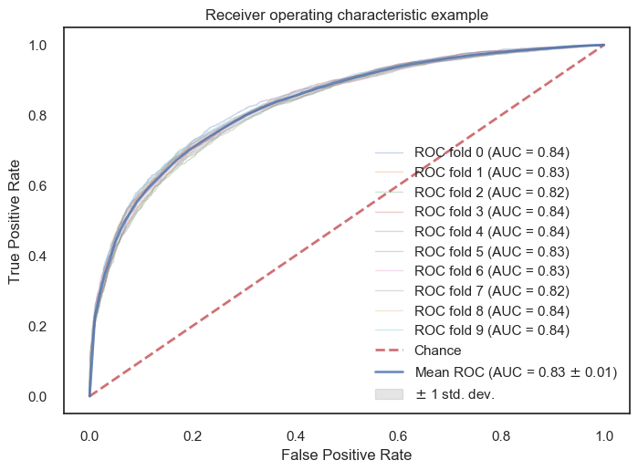

```python
# #############################################################################
# Data IO and generation

# Import some data to play with
X = np.array(input_vars[features])
y = np.array(output_var)


# #############################################################################
# Classification and ROC analysis

# Run classifier with cross-validation and plot ROC curves
cv = StratifiedKFold(n_splits=10)
classifier = clfs[hyperparameters["modelo"][max_index]].set_params(**hyperparameters.params[max_index])

tprs = []
aucs = []
mean_fpr = np.linspace(0, 1, 100)

i = 0
for train_index, test_index in cv.split(X, y):
    X_train, X_test = X[train_index], X[test_index]
    y_train, y_test = y[train_index], y[test_index]
    probas_ = classifier.fit(X_train, y_train).predict_proba(X_test)
    # Compute ROC curve and area the curve
    fpr, tpr, thresholds = roc_curve(y_test, probas_[:, 1])
    tprs.append(interp(mean_fpr, fpr, tpr))
    tprs[-1][0] = 0.0
    roc_auc = auc(fpr, tpr)
    aucs.append(roc_auc)
    plt.plot(fpr, tpr, lw=1, alpha=0.3,
             label='ROC fold %d (AUC = %0.2f)' % (i, roc_auc))

    i += 1

plt.plot([0, 1], [0, 1], linestyle='--', lw=2, color='r',
         label='Chance', alpha=.8)

mean_tpr = np.mean(tprs, axis=0)
mean_tpr[-1] = 1.0
mean_auc = auc(mean_fpr, mean_tpr)
std_auc = np.std(aucs)
plt.plot(mean_fpr, mean_tpr, color='b',
         label=r'Mean ROC (AUC = %0.2f $\pm$ %0.2f)' % (mean_auc, std_auc),
         lw=2, alpha=.8)

std_tpr = np.std(tprs, axis=0)
tprs_upper = np.minimum(mean_tpr + std_tpr, 1)
tprs_lower = np.maximum(mean_tpr - std_tpr, 0)
plt.fill_between(mean_fpr, tprs_lower, tprs_upper, color='grey', alpha=.2,
                 label=r'$\pm$ 1 std. dev.')

plt.xlim([-0.05, 1.05])
plt.ylim([-0.05, 1.05])
plt.xlabel('False Positive Rate')
plt.ylabel('True Positive Rate')
plt.title('Receiver operating characteristic example')
plt.legend(loc="lower right")
plt.show()
```

La curva de operación característica nos ayuda a ilustrar el desempeño de un clasificador binario a medida que varía su umbral de clasificación. En particular, se grafica la tasa de verdaderos positivos versus la tasa de falsos positivos predichos por el modelo.

Esta curva nos dice el abanico de posibilidades entre ratio de verdaderos positivos y falsos positivos. Y en particular nos ayuda a determinar la fortaleza de nuestro modelo bien sea para ser muy preciso en resultados de predicciones o recall.

Si consideramos el problema de la farmaceutica, por ejemplo, podríamos querer que nuestro modelo sea muy preciso en decirnos el público al que va a ir dirigido el anticonceptivo, y por tanto quisieramos que tuviera mucha presición, preferiríamos un modelo con ROC cercano a la esquina superior izquierda de la gráfica. En nuestro caso, el modelo está en un punto intermedio a este objetivo. Por otro lado, la AUC nos permite resumir el desempeño del modelo en una única medida, y por tanto nos resume la incormación de toda la curva ROC, como se indicó con anterioridad.